# Guided Action Flow · Đọc hiểu học thuật Anh–Việt có chú giải

Đến nội dung bài báo

Guided Action Flow: Value-Guided Sampling for Frozen Vision-Language-Action PoliciesHọc phần: Học máy cho Robot (Robot Learning) · Seminar đọc bài báo — Bản chú giải lập luận

Bản đồ lập luận ↘

Năm chiều phân tích · nhấn để bật/tắt

Annotated paper · Robot learning / VLA · EN / VI

# Guided Action Flow: Value-Guided Sampling for Frozen Vision-Language-Action Policies

Dẫn hướng lấy mẫu bằng hàm giá trị cho chính sách VLA đóng băng.

Liuhaichen Yang · Zhuang Jiang · Chenchao Sheng · Ningwei Bai · Qichen Yin · Hanbo Ma · Junkai Liu · Junkai Sun · Dongcheng Lyu · Yi Dong · Zezhi Tang

University College London · University of Manchester · Viện Công nghệ Phần mềm Nam Kinh (CAS) · University of Liverpool · arXiv:2607.02092v4 [cs.RO], 6/10/2026 · PDF 12 trang · 5 mục · 6 hình · 2 bảng · 12 công thức

**Luận điểm cần theo dõi**Không cần cập nhật tham số VLA: một critic nhỏ học từ kết quả thành/bại có thể “huých” từng bước lấy mẫu dòng ngược theo hướng có giá trị cao hơn, và chính *hướng* huých đó mới là phần tạo ra cải thiện.

**+22,5**điểm % thành công  
60,0 → 82,5% · Bảng 1

**+15,0**điểm % khi có nhiễu  
34,2 → 49,2% · Bảng 2

**2,735M**tham số critic  
VLA 0,45B giữ nguyên

**Cách đọc.** Mỗi đơn vị gồm nguyên văn tiếng Anh có tô màu theo năm chiều phân tích, bản dịch nghĩa tiếng Việt ngay bên dưới, và chú giải tương ứng ở cột phải (chức năng đoạn, vai trò logic, thủ pháp hoặc điểm yếu). Trên điện thoại, chú giải nằm sau bản dịch. Số § là mã đoạn của bản đọc này; số trang dẫn về PDF. Nhấn vào từng mục trong chú giải màu ở đầu trang để bật/tắt loại tô màu đó.

**Phạm vi biên tập.** Bao gồm toàn bộ văn xuôi chính (tóm tắt và Mục 1–5), 12 công thức gõ lại, chú thích và ảnh của 6 hình, số liệu đầy đủ của 2 bảng, và 40 tài liệu tham khảo được nhóm theo vai trò trong lập luận. Chỉ nối lại dòng và từ bị ngắt do dàn trang. Bản dịch và chú giải là phần biên soạn hỗ trợ học thuật, không phải nội dung do tác giả viết; các ước tính thống kê thêm (z, tỷ lệ thất bại) được ghi rõ là của người biên soạn.

**Nguồn.** [arXiv:2607.02092v4](https://arxiv.org/abs/2607.02092). Tệp hoạt động ngoại tuyến: font, hình, CSS và JavaScript đều được nhúng.

01 / Nguyên văn tiếng Anh + bản dịch tiếng Việt02 / Chức năng · Vai trò logic · Đánh giá

00

## Abstract Tóm tắt

Vấn đề, giải pháp và các con số trung tâm

§01PDF tr. 1EN → VI

Reinforcement learning can improve vision-language-action (VLA) policies beyond supervised fine-tuning, although this typically involves further updates to the policy parameters. For flow-matching policies, iterative action generation provides an additional opportunity to incorporate task information during inference. We introduce Guided Action Flow (GAF), which learns a compact, observation-conditioned action-value critic from robot task rollouts and applies its action gradient to steer reverse-time flow sampling. The supervised-fine-tuned VLA remains frozen throughout critic learning and deployment. Physical-robot experiments show an increase in aggregate success from 60.0% to 82.5% across six nominal manipulation tasks. Under six altered-lighting and object-distractor conditions evaluated on three of these tasks, aggregate success improves from 34.2% to 49.2%. Ablations and rollout analyses support the importance of the learned guidance direction and the critic’s visual and proprioceptive inputs. With approximately 2.735M trainable critic parameters alongside an unchanged 0.45B-parameter VLA, GAF enables task outcomes to inform action generation through a compact inference-time guidance module.

Bản dịch tiếng Việt

Học tăng cường có thể đưa chính sách thị giác–ngôn ngữ–hành động (VLA) vượt qua mức đạt được bằng tinh chỉnh có giám sát, song cách làm này thường đòi hỏi tiếp tục cập nhật tham số của chính sách. Với các chính sách dựa trên khớp dòng (flow matching), việc sinh hành động qua nhiều bước lặp mở ra thêm một cơ hội để đưa thông tin về nhiệm vụ vào ngay trong lúc suy luận. Chúng tôi đề xuất Guided Action Flow (GAF): học một bộ đánh giá giá trị hành động (critic) gọn nhẹ, có điều kiện theo quan sát, từ các lượt chạy thử nhiệm vụ trên robot, rồi dùng gradient của nó theo hành động để lái quá trình lấy mẫu dòng theo thời gian ngược. Mô hình VLA đã tinh chỉnh có giám sát được giữ đóng băng trong suốt quá trình học critic lẫn khi triển khai. Thí nghiệm trên robot thật cho thấy tỷ lệ thành công gộp tăng từ 60,0% lên 82,5% trên sáu nhiệm vụ thao tác ở điều kiện chuẩn. Trong sáu điều kiện thay đổi ánh sáng hoặc thêm vật gây nhiễu, đánh giá trên ba nhiệm vụ trong số đó, tỷ lệ thành công gộp tăng từ 34,2% lên 49,2%. Các thí nghiệm loại bỏ thành phần và phân tích lượt chạy ủng hộ vai trò của hướng dẫn hướng được học, cũng như của đầu vào thị giác và cảm nhận bản thể của critic. Chỉ với khoảng 2,735 triệu tham số huấn luyện được ở critic, đặt cạnh một VLA 0,45 tỷ tham số giữ nguyên, GAF cho phép kết quả nhiệm vụ tác động đến việc sinh hành động thông qua một mô-đun dẫn hướng gọn nhẹ ở thời điểm suy luận.

§01 · Luận đề

**① Chức năng đoạn**

### Tóm lược bài toán, giải pháp và kết quả

**② Vai trò logic**

Nén toàn bộ chuỗi lập luận vào một đoạn: RL hiệu quả nhưng phải cập nhật tham số → khớp dòng có “khe” để chen tín hiệu lúc suy luận → GAF → số liệu thành công → các thí nghiệm loại bỏ hậu thuẫn.

**③ Thủ pháp / điểm yếu tiềm ẩn**

Con số 2,735M được đặt cạnh 0,45B để nhấn mạnh tính gọn nhẹ, nhưng mỗi nhiệm vụ cần một critic riêng và thêm 40 lượt chạy trên robot thật; chi phí thực còn gồm dữ liệu và thời gian suy luận (10 lượt lan truyền ngược qua critic), không chỉ số tham số. Động từ “support” cho các thí nghiệm loại bỏ là mức khẳng định thận trọng, phù hợp.

Hình 1PDF tr. 1Ảnh trích từ PDF

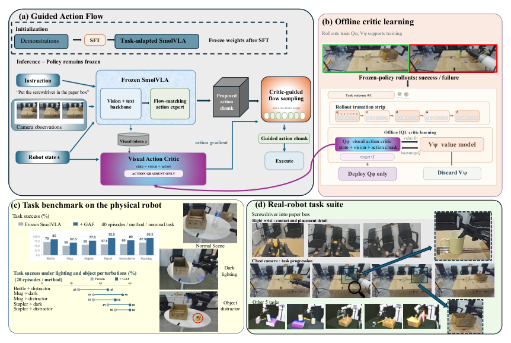

Figure 1. High-level summary of Guided Action Flow and its evaluation. (a) A compact action critic guides reverse-time sampling of a vision-language-action (VLA) policy frozen after supervised fine-tuning (SFT). (b) Task-rollout outcomes train the critic through offline implicit Q-learning (IQL). (c) Nominal task success and selected environment-perturbation results. (d) Qualitative executions from the six-task robot suite, including wrist- and chest-camera views.

Chú thích hình · tiếng Việt

Hình 1. Tổng quan GAF và cách đánh giá. (a) Một critic hành động gọn nhẹ dẫn hướng quá trình lấy mẫu theo thời gian ngược của chính sách VLA đã được đóng băng sau tinh chỉnh có giám sát (SFT). (b) Kết quả của các lượt chạy thử được dùng để huấn luyện critic bằng học Q ngầm (IQL) ngoại tuyến. (c) Tỷ lệ thành công ở điều kiện chuẩn và một số kết quả khi môi trường bị nhiễu. (d) Minh họa định tính trên bộ sáu nhiệm vụ, gồm góc nhìn camera cổ tay và camera ngực.

Hình 1 · Luận đề

**① Chức năng hình**

### Bản đồ trực quan của luận đề

**② Vai trò logic**

Gói cả bốn mắt xích (giải pháp, dữ liệu, bằng chứng, minh họa) vào một hình trước khi người đọc vào phần chữ.

**③ Thủ pháp / điểm yếu tiềm ẩn**

Ô (c) chỉ hiển thị năm trong sáu điều kiện nhiễu và bỏ đúng điều kiện có kết quả thấp nhất (Chai + đổi ánh sáng: 15% → 25%, Bảng 2). Chú thích có ghi “selected”, nhưng người đọc lướt dễ nhận một bức tranh lạc quan hơn dữ liệu đầy đủ.

1

## Introduction Mở đầu

Từ bối cảnh VLA đến câu hỏi nghiên cứu và đóng góp

§02PDF tr. 2EN → VI

Vision-language-action (VLA) models connect multimodal observations and language instructions to robot actions. Recent VLAs build on pretrained vision-language representations and robot demonstrations to support manipulation across tasks and embodiments [1–3].

Bản dịch tiếng Việt

Các mô hình thị giác–ngôn ngữ–hành động (VLA) nối quan sát đa phương thức và chỉ dẫn bằng ngôn ngữ với hành động của robot. Những VLA gần đây được xây dựng trên biểu diễn thị giác–ngôn ngữ đã tiền huấn luyện cùng dữ liệu thao tác mẫu của robot, nhờ đó có thể thao tác trên nhiều nhiệm vụ và nhiều dạng thân robot khác nhau [1–3].

§02 · Khái niệm

**① Chức năng đoạn**

### Đặt bối cảnh

**② Vai trò logic**

Mở màn chuỗi lập luận: xác định đối tượng (VLA) mà GAF sẽ can thiệp.

**③ Thủ pháp / điểm yếu tiềm ẩn**

Đoạn trung tính, không có tuyên bố gây tranh cãi; nhưng cũng chưa chỉ ra điểm yếu cụ thể nào của VLA mà bài báo sẽ khắc phục. Vấn đề chỉ lộ diện ở đoạn sau.

§03PDF tr. 2EN → VI

Supervised fine-tuning adapts these policies from demonstrations of desired behavior [2, 3]. Reinforcement-learning post-training uses task outcomes, preferences, or related behavioral signals to further optimize decisions [4–6]. In these settings, feedback is incorporated during post-training; we instead ask whether task-rollout outcomes can influence action generation at deployment while the supervised-fine-tuned VLA parameters remain fixed.

Bản dịch tiếng Việt

Tinh chỉnh có giám sát điều chỉnh các chính sách này dựa trên những thao tác mẫu thể hiện hành vi mong muốn [2, 3]. Hậu huấn luyện bằng học tăng cường thì khai thác kết quả nhiệm vụ, sở thích hoặc các tín hiệu hành vi liên quan để tối ưu quyết định thêm một bước [4–6]. Trong cả hai cách, phản hồi được đưa vào ở giai đoạn hậu huấn luyện. Ngược lại, chúng tôi đặt câu hỏi: liệu kết quả của các lượt chạy thử có thể tác động đến việc sinh hành động ngay khi triển khai, trong khi tham số của VLA đã tinh chỉnh vẫn được giữ cố định hay không?

§03 · Luận đề

**① Chức năng đoạn**

### Nêu câu hỏi nghiên cứu

**② Vai trò logic**

Mắt xích “câu hỏi”: tách trục “phản hồi được đưa vào lúc nào” (hậu huấn luyện hay triển khai). Chính trục này định vị đóng góp của GAF.

**③ Thủ pháp / điểm yếu tiềm ẩn**

Câu hỏi được nêu như một lựa chọn thiết kế nhưng chưa giải thích vì sao giữ VLA đóng băng là điều đáng mong muốn (tiết kiệm tính toán? tránh quên kiến thức? dùng chung một mô hình cho nhiều nhiệm vụ?). Động cơ này bị bỏ ngỏ đến hết bài.

§04PDF tr. 2EN → VI

Test-time guidance offers a way to apply related feedback after policy training. Existing methods use an auxiliary value, reward, or conditional objective to influence output generation without updating the policy [7, 8]. A flow-matching policy forms an action chunk through successive sampling steps, providing a natural point at which such a signal can be applied.

Bản dịch tiếng Việt

Dẫn hướng lúc kiểm thử (test-time guidance) cho phép áp dụng loại phản hồi tương tự sau khi chính sách đã huấn luyện xong. Các phương pháp hiện có dùng một hàm giá trị, hàm thưởng hoặc mục tiêu có điều kiện phụ trợ để chi phối quá trình sinh đầu ra mà không cập nhật chính sách [7, 8]. Vì chính sách khớp dòng tạo ra một khối hành động qua nhiều bước lấy mẫu liên tiếp, đó chính là điểm tự nhiên để chen một tín hiệu như vậy vào.

§04 · Khái niệm

**① Chức năng đoạn**

### Giới thiệu khái niệm then chốt và “điểm chèn”

**② Vai trò logic**

Cầu nối giữa câu hỏi (đoạn trước) và giải pháp (đoạn sau): lập luận rằng cấu trúc lặp của khớp dòng là chỗ can thiệp hợp lý.

**③ Thủ pháp / điểm yếu tiềm ẩn**

Tài liệu [8] (dẫn hướng gradient cho chính sách dòng trong RL) đã đề xuất cơ chế gần như tương tự; vì vậy tính mới của GAF nằm ở việc áp dụng vào VLA đa phương thức trên robot thật hơn là ở thuật toán. Bài báo thừa nhận điều này khá thẳng thắn ở Mục 2.3.

§05PDF tr. 2EN → VI

GAF instantiates this interface for a flow-matching VLA. It learns an observation-conditioned Q critic that takes proprioception, visual features, and a candidate action chunk as input. During reverse-time sampling, the critic gradient supplies a local correction to the action-generation velocity while the supervised-fine-tuned SmolVLA parameters remain fixed. Fig. 1 summarizes this interface and the evaluation. Guidance-direction and critic-input ablations examine the sources of the performance gains, while mechanism diagnostics characterize the critic scores and resulting action corrections. The paper therefore contributes an inference-time action-guidance layer for a frozen, supervised-fine-tuned flow-matching VLA and an evaluation across nominal tasks, controlled perturbations, ablations, and diagnostics.

Bản dịch tiếng Việt

GAF hiện thực hóa giao diện này cho một VLA khớp dòng. Phương pháp học một critic Q có điều kiện theo quan sát, nhận đầu vào là trạng thái cảm nhận bản thể, đặc trưng thị giác và một khối hành động ứng viên. Trong quá trình lấy mẫu theo thời gian ngược, gradient của critic cung cấp một hiệu chỉnh cục bộ cho vận tốc sinh hành động, còn tham số SmolVLA đã tinh chỉnh vẫn giữ nguyên. Hình 1 tóm lược giao diện này cùng cách đánh giá. Các thí nghiệm loại bỏ về hướng dẫn hướng và đầu vào của critic được dùng để truy nguồn gốc của mức cải thiện, còn các phân tích cơ chế mô tả điểm số của critic và những hiệu chỉnh hành động mà nó tạo ra. Như vậy, đóng góp của bài báo gồm một lớp dẫn hướng hành động ở thời điểm suy luận cho VLA khớp dòng đã tinh chỉnh và đóng băng, cùng một đánh giá bao quát điều kiện chuẩn, nhiễu có kiểm soát, thí nghiệm loại bỏ và phân tích chẩn đoán.

§05 · Luận đề

**① Chức năng đoạn**

### Tuyên bố giải pháp và đóng góp

**② Vai trò logic**

Chốt phần mở đầu; liệt kê trước bốn loại bằng chứng sẽ xuất hiện ở Mục 4, có thể dùng như một danh sách kiểm tra khi đọc.

**③ Thủ pháp / điểm yếu tiềm ẩn**

Đóng góp được phát biểu khiêm tốn (“một lớp dẫn hướng” và “một đánh giá”), tương xứng với dữ liệu. Tuy vậy không có đối chứng nào với phương pháp xếp hạng lại ứng viên [7] hay hậu huấn luyện RL dùng cùng dữ liệu, nên đóng góp chỉ được kiểm chứng so với phương án “không làm gì”.

2

## Related Work Nghiên cứu liên quan

Định vị GAF giữa VLA, cải thiện chính sách bằng phản hồi và dẫn hướng lúc kiểm thử

### 2.1 · Vision-Language-Action Policies · Chính sách VLA

§06PDF tr. 2EN → VI

Learned visual representations support object detection for manipulation [9] and VLA models that map observations and instructions to actions [1, 2, 10]. Generalist robot policies learn from demonstrations spanning tasks and embodiments, providing an initialization that can be adapted to new control settings [2, 11]. Their action representations range from discrete tokens to continuous chunks generated through diffusion or flow sampling [2, 3, 11–13]. GAF uses the flow-matching interface as the point at which task feedback can influence inference.

Bản dịch tiếng Việt

Biểu diễn thị giác học được hỗ trợ việc phát hiện vật thể phục vụ thao tác [9] cũng như các mô hình VLA ánh xạ quan sát và chỉ dẫn thành hành động [1, 2, 10]. Các chính sách robot tổng quát học từ thao tác mẫu trải rộng nhiều nhiệm vụ và dạng thân robot, tạo ra một điểm khởi đầu có thể thích nghi với bối cảnh điều khiển mới [2, 11]. Cách biểu diễn hành động của chúng đi từ token rời rạc đến các khối liên tục được sinh bằng lấy mẫu khuếch tán hoặc khớp dòng [2, 3, 11–13]. GAF chọn chính giao diện khớp dòng làm nơi để phản hồi nhiệm vụ tác động vào quá trình suy luận.

§06 · Khái niệm

**① Chức năng đoạn**

### Định vị trong dòng nghiên cứu VLA

**② Vai trò logic**

Thu hẹp phạm vi: trong các cách biểu diễn hành động, chỉ dạng sinh lặp (khuếch tán/khớp dòng) mới có “bước trung gian” để dẫn hướng.

**③ Thủ pháp / điểm yếu tiềm ẩn**

Câu cuối ngầm cho biết GAF chỉ áp dụng được cho VLA sinh hành động liên tục, không dùng trực tiếp cho VLA token rời rạc như RT-2 hay OpenVLA. Đây là một giới hạn phạm vi quan trọng nhưng không được nói rõ thành hạn chế.

### 2.2 · Feedback-Based Control and Policy Improvement · Điều khiển phản hồi và cải thiện chính sách

§07PDF tr. 2EN → VI

Feedback-based control offers several ways to improve behavior under uncertainty, including disturbance estimation and compensation [14–17] and tracking and stabilization with reinforcement learning [18–21]. Coordination and distributed optimization [22–24] address interactions between agents, while robustness testing [25] examines system behavior under adverse conditions. For learned policies, a key distinction is whether feedback updates the policy parameters or influences how actions are selected.

Bản dịch tiếng Việt

Điều khiển dựa trên phản hồi cung cấp nhiều cách cải thiện hành vi trong điều kiện bất định, chẳng hạn ước lượng và bù nhiễu [14–17] hay bám quỹ đạo và ổn định hóa bằng học tăng cường [18–21]. Bài toán phối hợp và tối ưu phân tán [22–24] xử lý tương tác giữa các tác tử, còn kiểm thử độ bền vững [25] xem xét hành vi hệ thống trong điều kiện bất lợi. Với chính sách học được, điểm phân biệt then chốt là phản hồi sẽ cập nhật tham số của chính sách hay chỉ tác động lên cách lựa chọn hành động.

§07 · Khái niệm

**① Chức năng đoạn**

### Mở rộng bối cảnh và đưa ra một phép phân loại

**② Vai trò logic**

Câu cuối là phần có giá trị logic: lập trục “cập nhật tham số” và “tác động vào cách chọn hành động”. GAF thuộc nhánh thứ hai.

**③ Thủ pháp / điểm yếu tiềm ẩn**

Cả 12 trích dẫn [14–25] đều có tên tác giả liên hệ của bài (Z. Tang) và bàn về ổ từ, phủ màng, đa tác tử… Liên hệ với VLA rất mờ. Đây là điểm yếu về tính chọn lọc của tổng quan, có dấu hiệu tự trích dẫn.

§08PDF tr. 2EN → VI

In language-model post-training, preferences, process supervision, data selection, and group-based objectives provide several routes to policy improvement [26–31]; complementary analyses examine stability, efficiency, and evaluation [32, 33].

Bản dịch tiếng Việt

Trong hậu huấn luyện mô hình ngôn ngữ, học từ sở thích, giám sát theo quá trình, chọn lọc dữ liệu và các mục tiêu tối ưu theo nhóm là những con đường khác nhau để cải thiện chính sách [26–31]; một số phân tích bổ sung xem xét tính ổn định, hiệu quả và cách đánh giá [32, 33].

§08 · Khái niệm

**① Chức năng đoạn**

### Liên hệ chéo lĩnh vực

**② Vai trò logic**

Gợi ý rằng ý tưởng “dùng phản hồi nhiệm vụ để cải thiện chính sách” đã thành công ở mô hình ngôn ngữ lớn, qua đó tạo tính chính danh cho hướng tiếp cận.

**③ Thủ pháp / điểm yếu tiềm ẩn**

Đoạn chỉ liệt kê, không rút ra bài học nào cho robot. Các tài liệu này đều thuộc nhánh cập nhật tham số nên không trực tiếp hỗ trợ lựa chọn đóng băng của GAF. [32, 33] cũng là công trình của tác giả thứ nhất.

§09PDF tr. 2–3EN → VI

Robot-learning systems expose related design choices under continuous actions, partial observability, and physical interaction constraints. Value-based methods estimate action values for control or policy extraction [34, 35]; other methods use rollout outcomes to update tokenized or continuous VLA policies directly [4–6]. Offline-to-online approaches combine demonstrations, value learning, and subsequent policy updates for robot adaptation [36]. GAF trains an auxiliary critic from task rollouts and applies it during inference while leaving the VLA fixed.

Bản dịch tiếng Việt

Các hệ thống học robot gặp những lựa chọn thiết kế tương tự, nhưng trong bối cảnh hành động liên tục, quan sát không đầy đủ và ràng buộc tương tác vật lý. Các phương pháp dựa trên giá trị ước lượng giá trị của hành động để điều khiển hoặc trích xuất chính sách [34, 35]; một số phương pháp khác dùng kết quả chạy thử để cập nhật trực tiếp chính sách VLA dạng token hoặc dạng liên tục [4–6]. Hướng tiếp cận từ ngoại tuyến sang trực tuyến kết hợp thao tác mẫu, học hàm giá trị và các bước cập nhật chính sách tiếp theo để robot thích nghi [36]. GAF huấn luyện một critic phụ trợ từ các lượt chạy thử và chỉ dùng nó khi suy luận, còn VLA được giữ nguyên.

§09 · Khái niệm

**① Chức năng đoạn**

### So sánh để phân biệt

**② Vai trò logic**

Đặt GAF giữa hai nhóm: dùng hàm giá trị như nhóm value-based, nhưng không cập nhật chính sách như [4–6, 36].

**③ Thủ pháp / điểm yếu tiềm ẩn**

Kỹ thuật “định vị bằng loại trừ” rõ ràng. Nhưng [4–6, 36] chính là các đối thủ tự nhiên dùng cùng loại dữ liệu chạy thử; thiếu thí nghiệm so sánh với chúng khiến luận điểm “không cần cập nhật tham số mà vẫn hiệu quả” chưa được cân đo về chi phí và lợi ích.

### 2.3 · Test-Time Guidance · Dẫn hướng lúc kiểm thử

§10PDF tr. 3EN → VI

After policy training, the same feedback can be applied at the point where a model produces its output. Test-time guidance uses an auxiliary objective to influence inference without changing the pretrained model. Classifier guidance and classifier-free guidance modify image-sampling trajectories with an additional conditional signal [37, 38]; in sequential decision-making, learned reward or value models can similarly bias generated trajectories or action sequences [39]. The common feature is that task information acts during output generation.

Bản dịch tiếng Việt

Sau khi chính sách đã huấn luyện xong, cùng loại phản hồi ấy vẫn có thể được áp dụng tại thời điểm mô hình tạo ra đầu ra. Dẫn hướng lúc kiểm thử dùng một mục tiêu phụ trợ để chi phối quá trình suy luận mà không thay đổi mô hình đã tiền huấn luyện. Dẫn hướng bằng bộ phân loại và dẫn hướng không cần bộ phân loại điều chỉnh quỹ đạo lấy mẫu ảnh bằng một tín hiệu điều kiện bổ sung [37, 38]; trong ra quyết định tuần tự, mô hình thưởng hoặc giá trị học được cũng có thể làm lệch các quỹ đạo hay chuỗi hành động được sinh ra theo cách tương tự [39]. Điểm chung là thông tin nhiệm vụ phát huy tác dụng ngay trong lúc sinh đầu ra.

§10 · Khái niệm

**① Chức năng đoạn**

### Truy nguồn gốc khái niệm

**② Vai trò logic**

Cung cấp “phả hệ” cho cơ chế của GAF: từ dẫn hướng bằng bộ phân loại trong sinh ảnh đến Diffuser trong ra quyết định.

**③ Thủ pháp / điểm yếu tiềm ẩn**

Phép loại suy với sinh ảnh hợp lý về hình thức, nhưng bỏ qua một khác biệt cốt lõi: ở robot, sai lệch nhỏ của hành động tích lũy qua vòng kín và có thể gây va chạm. Rủi ro này chỉ được nhắc rất ngắn ở Mục 3.6.

§11PDF tr. 3EN → VI

Candidate-based methods generate multiple proposals and use a learned evaluator to rerank or select them, as in value-guided policy steering [7, 40]. Gradient-based flow guidance instead modifies an intermediate sample during iterative generation and can obtain a critic gradient at an estimate of the completed action without differentiating through the full sampling trajectory [8]. GAF applies this interface to a multimodal flow-matching VLA, using a task-rollout-trained critic conditioned on visual features, proprioception, and action chunks, and evaluates it on robot manipulation tasks.

Bản dịch tiếng Việt

Các phương pháp dựa trên ứng viên sinh ra nhiều phương án rồi dùng một bộ đánh giá học được để xếp hạng lại hoặc chọn lựa, như trong lái chính sách bằng hàm giá trị [7, 40]. Dẫn hướng dòng dựa trên gradient thì khác: nó sửa trực tiếp mẫu trung gian trong quá trình sinh lặp, và có thể lấy gradient của critic tại một ước lượng của hành động hoàn chỉnh mà không phải lấy vi phân qua toàn bộ quỹ đạo lấy mẫu [8]. GAF áp dụng giao diện này cho một VLA khớp dòng đa phương thức, dùng critic huấn luyện từ các lượt chạy thử và có điều kiện theo đặc trưng thị giác, trạng thái cảm nhận bản thể cùng khối hành động, rồi đánh giá trên các nhiệm vụ thao tác robot.

§11 · Luận đề

**① Chức năng đoạn**

### Xác định khoảng trống và tính mới

**② Vai trò logic**

Đỉnh của phần tổng quan: chọn nhánh gradient thay vì nhánh xếp hạng ứng viên, và khẳng định đóng góp là ứng dụng vào VLA đa phương thức.

**③ Thủ pháp / điểm yếu tiềm ẩn**

Thẳng thắn về nguồn gốc kỹ thuật ([8]). Điểm yếu: bài không lý giải vì sao chọn gradient thay vì xếp hạng ứng viên ([7]) và cũng không đo so sánh, dù Hình 6(d) đã dùng bốn ứng viên, tức hạ tầng cho phương án xếp hạng đã có sẵn.

3.1–3.2

## Method · Overview & Policy Phương pháp · Tổng quan và khởi tạo chính sách

Quy trình ba giai đoạn và không gian hành động

### 3.1 · System Overview · Tổng quan hệ thống

§12PDF tr. 3EN → VI

Fig. 2 summarizes the GAF pipeline. Human demonstrations first initialize the task policy. The resulting SmolVLA policy is then kept fixed while robot task rollouts provide the data for an observation-conditioned action critic. During deployment, the critic gradient modifies the reverse-time flow computation before the generated action chunk is executed. The VLA generates the base multimodal action chunk, and GAF modifies the sampling velocity used to produce it.

Bản dịch tiếng Việt

Hình 2 tóm tắt quy trình của GAF. Trước tiên, thao tác mẫu của con người được dùng để khởi tạo chính sách cho nhiệm vụ. Chính sách SmolVLA thu được sau đó được giữ cố định, còn các lượt chạy thử trên robot cung cấp dữ liệu để huấn luyện critic hành động có điều kiện theo quan sát. Khi triển khai, gradient của critic điều chỉnh phép tính dòng theo thời gian ngược trước khi khối hành động được thực thi. Nói cách khác, VLA sinh ra khối hành động đa phương thức cơ sở, còn GAF điều chỉnh vận tốc lấy mẫu dùng để tạo ra khối hành động đó.

§12 · Phương pháp

**① Chức năng đoạn**

### Phác thảo quy trình ba giai đoạn

**② Vai trò logic**

Bản đồ cho Mục 3: SFT (3.2) → dữ liệu chạy thử (3.3) → critic IQL (3.4) → dẫn hướng (3.5).

**③ Thủ pháp / điểm yếu tiềm ẩn**

Câu cuối phân vai rõ (VLA đề xuất, GAF chỉnh), giúp hiểu vì sao “đóng băng” không mâu thuẫn với “cải thiện”. Lưu ý: dữ liệu của critic đến từ chính chính sách đóng băng, nên critic chỉ học được trong vùng phân bố mà chính sách đã đi qua.

### 3.2 · Policy Initialization and Action Interface · Khởi tạo chính sách và giao diện hành động

§13PDF tr. 3EN → VI

We first obtain the policy by supervised fine-tuning SmolVLA on human expert demonstrations, as illustrated in Fig. 2(A). We use 50 expert teleoperation demonstrations for each task, with 40 used for supervised fine-tuning and 10 held out for validation. After this initialization, all SmolVLA parameters remain fixed during critic learning and guided inference.

Bản dịch tiếng Việt

Trước hết, chúng tôi có được chính sách bằng cách tinh chỉnh có giám sát SmolVLA trên thao tác mẫu của chuyên gia, như minh họa ở Hình 2(A). Mỗi nhiệm vụ dùng 50 lượt thao tác mẫu điều khiển từ xa: 40 lượt cho tinh chỉnh và 10 lượt giữ lại để kiểm định. Sau bước khởi tạo này, toàn bộ tham số SmolVLA được giữ cố định trong cả giai đoạn học critic lẫn suy luận có dẫn hướng.

§13 · Phương pháp

**① Chức năng đoạn**

### Mô tả điểm xuất phát (baseline)

**② Vai trò logic**

Xác lập “chính sách đóng băng”, đối chứng duy nhất mà mọi con số về sau đều so sánh với.

**③ Thủ pháp / điểm yếu tiềm ẩn**

Chỉ 40 lượt mẫu cho SFT khiến baseline tương đối yếu (60% thành công). Dẫn hướng có thể dễ tạo khác biệt hơn khi baseline còn nhiều dư địa; chưa biết GAF còn giúp được bao nhiêu nếu VLA được tinh chỉnh tốt hơn.

§14PDF tr. 3EN → VI

At each policy step, the robot observation includes the proprioceptive state and the current camera observations. For the robot used in our experiments, the proprioceptive state is an 8-dimensional vector s = [q<sub>1</sub>, …, q<sub>7</sub>, g<sub>grip</sub>](1) where q<sub>i</sub> are the seven joint angles and g<sub>grip</sub> is the binary gripper state. The VLA maps this multimodal observation and the language instruction to a continuous action chunk a<sub>0:H−1</sub> ∈ ℝ<sup>H×d<sub>a</sub></sup>, H = 50, d<sub>a</sub> = 8(2) containing seven joint channels and one gripper channel. Critic training and guidance both use this chunk in the policy’s normalized action space.

Bản dịch tiếng Việt

Ở mỗi bước của chính sách, quan sát của robot gồm trạng thái cảm nhận bản thể và hình ảnh camera hiện tại. Với robot dùng trong thí nghiệm, trạng thái cảm nhận bản thể là một vectơ 8 chiều (1), trong đó qᵢ là bảy góc khớp và g<sub>grip</sub> là trạng thái nhị phân của bộ kẹp. VLA ánh xạ quan sát đa phương thức này cùng chỉ dẫn ngôn ngữ thành một khối hành động liên tục (2), gồm bảy kênh khớp và một kênh bộ kẹp. Cả việc huấn luyện critic lẫn dẫn hướng đều thao tác trên khối hành động này trong không gian hành động đã chuẩn hóa của chính sách.

§14 · Phương pháp

**① Chức năng đoạn**

### Định nghĩa đối tượng toán học

**② Vai trò logic**

Xác định không gian mà gradient của critic tác động: khối 50 × 8 = 400 chiều.

**③ Thủ pháp / điểm yếu tiềm ẩn**

Bộ kẹp vốn nhị phân nhưng được sinh như một kênh liên tục, và gradient dẫn hướng tác động lên cả kênh này (Hình 6c cho thấy độ lệch ở bộ kẹp lớn hơn ở các khớp). Ngoài ra, 50 bước ở 15 Hz ≈ 3,3 giây; bài không nói bao nhiêu bước của khối được thực thi trước khi sinh khối mới.

Hình 2PDF tr. 4Ảnh trích từ PDF

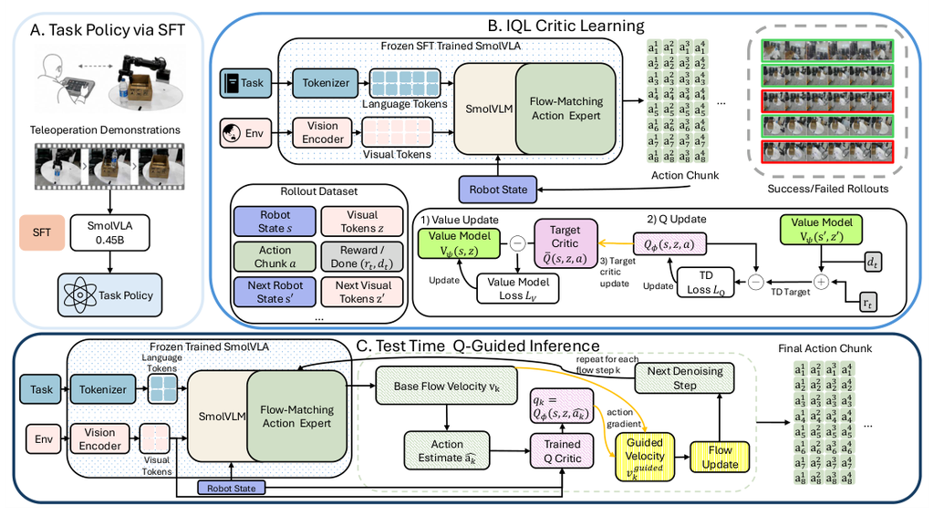

Figure 2. Detailed GAF training and inference pipeline. (A) Human demonstrations are used to fine-tune SmolVLA. (B) Rollouts from the frozen policy train an action critic and a value model with offline IQL and temporal-difference (TD) critic updates. (C) At each reverse-time flow step, the critic gradient at the estimated action chunk adjusts the sampling velocity. The VLA parameters remain fixed throughout (B) and (C); the value model is used only during training.

Chú thích hình · tiếng Việt

Hình 2. Quy trình huấn luyện và suy luận chi tiết của GAF. (A) Thao tác mẫu của con người được dùng để tinh chỉnh SmolVLA. (B) Các lượt chạy thử của chính sách đóng băng được dùng để huấn luyện critic hành động và mô hình giá trị bằng IQL ngoại tuyến cùng các bước cập nhật sai phân thời gian (TD). (C) Ở mỗi bước dòng ngược, gradient của critic tại khối hành động ước lượng điều chỉnh vận tốc lấy mẫu. Tham số VLA giữ cố định suốt (B) và (C); mô hình giá trị chỉ dùng khi huấn luyện.

Hình 2 · Phương pháp

**① Chức năng hình**

### Sơ đồ kiến trúc chi tiết

**② Vai trò logic**

Trực quan hóa ranh giới “đóng băng” và luồng gradient, xương sống của luận đề.

**③ Thủ pháp / điểm yếu tiềm ẩn**

Sơ đồ có vòng “lặp lại cho mỗi bước dòng k” nhưng không ghi chi phí: mỗi bước cần một lượt tiến–lùi qua critic Transformer với 128 token thị giác 960 chiều. Độ trễ không được báo cáo ở bất kỳ đâu trong bài.

3.3–3.4

## Rollout Data & IQL Critic Dữ liệu chạy thử và critic IQL

Tín hiệu nhiệm vụ đến từ đâu và được học như thế nào

### 3.3 · Task Rollout Dataset · Dữ liệu lượt chạy thử

§15PDF tr. 4EN → VI

Following policy initialization, the frozen policy is deployed to collect task rollouts for critic training, as shown in Fig. 2(B). We collect 40 rollouts per task, including successful and unsuccessful executions, to train a critic for that task. Each tuple is defined at the policy/chunk level: s denotes the current proprioceptive state, z the frozen vision-encoder features extracted from the current camera observations, and a ≡ a<sub>0:H−1</sub> the complete action chunk. After executing the chunk, s′ and z′ denote the next proprioceptive state and visual features. The binary task reward is r ∈ {0, 1}, and d ∈ {0, 1} indicates whether the transition terminates the episode: nonterminal chunks have (r, d) = (0, 0), while the terminal chunk has d = 1 and receives r = 1 on success or r = 0 on failure.

Bản dịch tiếng Việt

Sau bước khởi tạo, chính sách đóng băng được đưa vào chạy để thu thập các lượt thực hiện nhiệm vụ phục vụ huấn luyện critic, như ở Hình 2(B). Mỗi nhiệm vụ thu 40 lượt chạy, gồm cả lượt thành công lẫn thất bại, để huấn luyện một critic riêng cho nhiệm vụ đó. Mỗi bộ dữ liệu được định nghĩa ở cấp chính sách/khối hành động: s là trạng thái cảm nhận bản thể hiện tại, z là đặc trưng do bộ mã hóa thị giác (đóng băng) trích từ ảnh camera hiện tại, và a là toàn bộ khối hành động. Sau khi thực thi khối, s′ và z′ là trạng thái và đặc trưng thị giác kế tiếp. Phần thưởng nhiệm vụ là nhị phân, r ∈ {0, 1}, còn d ∈ {0, 1} cho biết bước chuyển có kết thúc lượt chạy hay không: các khối chưa kết thúc có (r, d) = (0, 0); khối cuối có d = 1 và nhận r = 1 nếu thành công, r = 0 nếu thất bại.

§15 · Phương pháp

**① Chức năng đoạn**

### Định nghĩa dữ liệu và tín hiệu thưởng

**② Vai trò logic**

Nền tảng của toàn bộ “tín hiệu nhiệm vụ”: critic chỉ biết thành hay bại ở cuối lượt, không có thưởng trung gian.

**③ Thủ pháp / điểm yếu tiềm ẩn**

Thưởng thưa cộng với chỉ 40 lượt mỗi nhiệm vụ là rất ít cho học giá trị ngoại tuyến; điều này khiến kết quả AUROC (Hình 6a) đáng chú ý nhưng cũng dễ quá khớp. Điểm chưa rõ: 40 lượt đánh giá baseline ở Mục 4 có trùng với 40 lượt dùng để huấn luyện critic hay không. Bài không nói.

§16PDF tr. 4EN → VI

The dataset is split by episode so that chunks from one rollout do not appear in both training and validation sets. The discount factor is applied per action chunk rather than per low-level control step.

Bản dịch tiếng Việt

Dữ liệu được chia theo lượt chạy, để các khối của cùng một lượt không đồng thời xuất hiện ở tập huấn luyện và tập kiểm định. Hệ số chiết khấu được áp dụng theo từng khối hành động chứ không theo từng bước điều khiển cấp thấp.

§16 · Phương pháp

**① Chức năng đoạn**

### Chi tiết chống rò rỉ dữ liệu

**② Vai trò logic**

Bảo vệ tính hợp lệ của việc chọn checkpoint theo TD loss kiểm định (Mục 3.4).

**③ Thủ pháp / điểm yếu tiềm ẩn**

Đây là thực hành tốt, thường bị bỏ qua. Nhưng với 40 lượt mỗi nhiệm vụ, tập kiểm định chỉ gồm vài lượt nên tiêu chí chọn checkpoint sẽ nhiễu. Tỷ lệ chia không được nêu.

### 3.4 · Action Critic and IQL Training · Critic hành động và huấn luyện IQL

§17PDF tr. 4EN → VI

The observation-conditioned action critic Q<sub>ϕ</sub> in Fig. 3 assigns a task-value estimate to an action chunk in the current observation. The critic takes the proprioceptive state, visual features, and the complete action chunk as inputs and outputs a scalar value. In the implementation, these inputs are fused by a Transformer-based critic network with a 256-dimensional hidden representation, three Transformer layers, and four attention heads. Each action critic contains approximately 2.735M trainable parameters, excluding the frozen visual feature extractor.

Bản dịch tiếng Việt

Critic hành động Q<sub>ϕ</sub> có điều kiện theo quan sát (Hình 3) gán cho mỗi khối hành động một ước lượng giá trị nhiệm vụ trong bối cảnh quan sát hiện tại. Critic nhận trạng thái cảm nhận bản thể, đặc trưng thị giác và toàn bộ khối hành động làm đầu vào, rồi xuất ra một giá trị vô hướng. Trong cài đặt, các đầu vào này được hợp nhất bằng một mạng Transformer với biểu diễn ẩn 256 chiều, ba lớp Transformer và bốn đầu chú ý. Mỗi critic có khoảng 2,735 triệu tham số huấn luyện được, chưa tính bộ trích đặc trưng thị giác đóng băng.

§17 · Khái niệm

**① Chức năng đoạn**

### Định nghĩa thành phần trung tâm

**② Vai trò logic**

Critic là “nguồn tri thức nhiệm vụ” duy nhất mà GAF thêm vào; kích thước nhỏ là luận cứ cho tính gọn nhẹ.

**③ Thủ pháp / điểm yếu tiềm ẩn**

Con số 2,735M loại trừ bộ trích đặc trưng. Điều này hợp lý vì bộ trích dùng chung với VLA, nhưng cũng có nghĩa critic phụ thuộc vào biểu diễn thị giác của chính VLA. Hình 3 ghi “2.74 M” (làm tròn), nhất quán với chữ.

§18PDF tr. 4–5EN → VI

A separate value model V<sub>ψ</sub> is used only during offline IQL training [35]. Using the transition quantities defined above, the value model is trained by expectile regression with a slowly updated target critic Q; targets are detached during each update: δ = Q(s, z, a) − V<sub>ψ</sub>(s, z)(3)L<sub>V</sub> = 𝔼[ w(δ) δ<sup>2</sup> ], w(δ) = 0.7 if δ > 0; 0.3 if δ ≤ 0(4)

Bản dịch tiếng Việt

Một mô hình giá trị riêng V<sub>ψ</sub> chỉ được dùng trong quá trình huấn luyện IQL ngoại tuyến [35]. Dựa trên các đại lượng chuyển trạng thái đã định nghĩa, mô hình giá trị được huấn luyện bằng hồi quy expectile so với một critic đích Q̄ được cập nhật chậm; các giá trị đích được tách khỏi đồ thị gradient trong mỗi lần cập nhật, theo (3) và (4).

§18 · Phương pháp

**① Chức năng đoạn**

### Giải thích kỹ thuật học giá trị

**② Vai trò logic**

Lý do chọn IQL: học giá trị “tốt hơn mức trung bình” chỉ từ dữ liệu có sẵn, không cần truy vấn hành động ngoài phân bố.

**③ Thủ pháp / điểm yếu tiềm ẩn**

Trọng số bất đối xứng 0,7/0,3 khiến V<sub>ψ</sub> xấp xỉ một expectile trên của Q, tức “giá trị của những hành động tốt có trong dữ liệu”. Bài không giải thích trực giác này cho người đọc ngoài chuyên ngành RL và không phân tích độ nhạy theo mức expectile.

§19PDF tr. 5EN → VI

The critic is trained with the temporal-difference (TD) target y = r + γ(1 − d) V<sub>ψ</sub>(s′, z′)(5)L<sub>Q</sub> = 𝔼[ (Q<sub>ϕ</sub>(s, z, a) − y)<sup>2</sup> ](6)

Bản dịch tiếng Việt

Critic được huấn luyện với mục tiêu sai phân thời gian (TD) theo (5) và hàm mất mát bình phương theo (6).

§19 · Phương pháp

**① Chức năng đoạn**

### Công thức cập nhật critic

**② Vai trò logic**

Lan truyền thưởng thành/bại ở cuối lượt ngược về các khối trước thông qua V<sub>ψ</sub>(s′, z′).

**③ Thủ pháp / điểm yếu tiềm ẩn**

Dùng V thay cho max Q ở mục tiêu là cốt lõi của IQL, giúp tránh ước lượng quá cao cho hành động ngoài dữ liệu. Nhưng khi suy luận, GAF lại lấy ∇Q tại những hành động có thể lệch khỏi dữ liệu, đúng vùng mà IQL được thiết kế để tránh truy vấn. Độ lớn hiệu chỉnh nhỏ (Hình 6b) phần nào hạn chế rủi ro này.

§20PDF tr. 5EN → VI

Here d is the termination indicator and γ is the chunk-level discount factor. The target critic is updated by Q ← τQ + (1 − τ)Q with Polyak coefficient τ = 0.005. We use γ = 0.99, expectile 0.7, AdamW with learning rate 3 × 10<sup>−4</sup> and weight decay 10<sup>−4</sup>, batch size 16, and at most 80 training epochs. The checkpoint with the lowest validation TD loss is selected. The value model is discarded after training; only Q<sub>ϕ</sub> is used during inference.

Bản dịch tiếng Việt

Ở đây, d là chỉ báo kết thúc và γ là hệ số chiết khấu theo khối. Critic đích được cập nhật theo Q̄ ← τQ + (1 − τ)Q̄ với hệ số Polyak τ = 0,005. Chúng tôi dùng γ = 0,99, expectile 0,7, bộ tối ưu AdamW với tốc độ học 3 × 10⁻⁴ và suy giảm trọng số 10⁻⁴, kích thước lô 16 và tối đa 80 epoch. Checkpoint có TD loss kiểm định thấp nhất được chọn. Mô hình giá trị bị loại bỏ sau huấn luyện; khi suy luận chỉ dùng Q<sub>ϕ</sub>.

§20 · Phương pháp

**① Chức năng đoạn**

### Siêu tham số và tiêu chí chọn mô hình

**② Vai trò logic**

Đảm bảo khả năng tái lập; khẳng định chỉ một mạng nhỏ được đưa vào triển khai.

**③ Thủ pháp / điểm yếu tiềm ẩn**

TD loss thấp không bảo đảm gradient ∇Q theo hành động có ý nghĩa, mà gradient mới là thứ GAF thực sự dùng. Không có thí nghiệm nào liên hệ chất lượng checkpoint với thành công khi dẫn hướng, và số seed huấn luyện không được báo cáo.

Hình 3PDF tr. 5Ảnh trích từ PDF

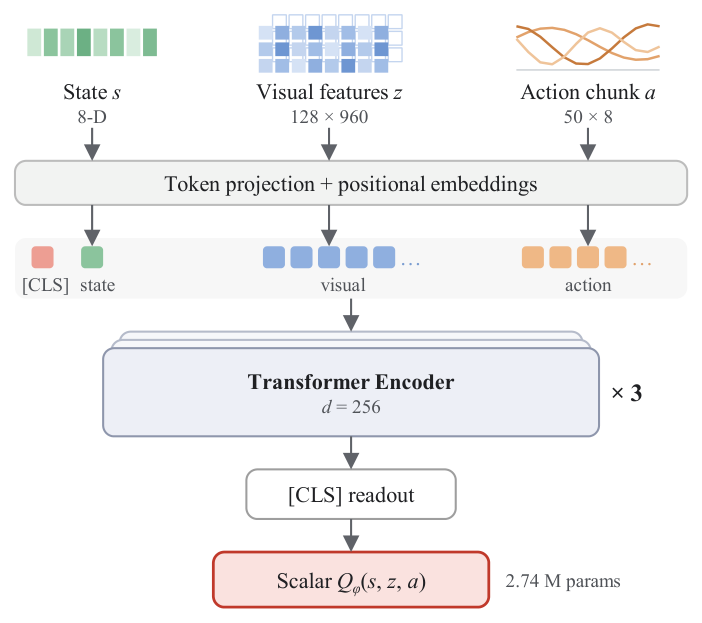

Figure 3. Action-critic architecture. Proprioceptive state, visual features, and the 50-step action chunk are projected into a common token space, processed by a Transformer encoder, and mapped from the classification ([CLS]) token to the scalar action-value estimate Q<sub>ϕ</sub>(s, z, a).

Chú thích hình · tiếng Việt

Hình 3. Kiến trúc critic hành động. Trạng thái cảm nhận bản thể, đặc trưng thị giác và khối hành động 50 bước được chiếu vào cùng một không gian token, xử lý bằng bộ mã hóa Transformer, rồi từ token phân loại ([CLS]) ánh xạ ra ước lượng giá trị hành động vô hướng Q<sub>ϕ</sub>(s, z, a).

Hình 3 · Phương pháp

**① Chức năng hình**

### Kiến trúc critic

**② Vai trò logic**

Cho thấy critic “nhìn” cả ba nguồn thông tin, làm cơ sở cho thí nghiệm bỏ đầu vào ở Hình 5(b).

**③ Thủ pháp / điểm yếu tiềm ẩn**

Có 128 token thị giác nhưng chỉ một token trạng thái, nên dễ hiểu vì sao bỏ thị giác gây hại. Việc bỏ một token trạng thái cũng gây hại gần tương đương (−17,5 điểm) là kết quả đáng chú ý mà bài chưa giải thích.

3.5–3.6

## Guidance During Reverse-Time Flow Dẫn hướng trong dòng ngược

Cơ chế cốt lõi và ranh giới an toàn

### 3.5 · GAF Guidance During Reverse-Time Flow · Dẫn hướng GAF trong dòng ngược

§21PDF tr. 5EN → VI

The frozen SmolVLA sampler follows a reverse-time flow convention. For the flow-matching parameterization used here, the training interpolation and target velocity are x<sub>t</sub> = tϵ + (1 − t)a, v<sub>t</sub><sup>∗</sup> = ϵ − a(7) where a is a clean action chunk and ϵ is Gaussian noise. At inference, the policy predicts v<sub>t</sub> = v<sub>θ</sub>(x<sub>t</sub>, t | o, ℓ), conditioned on the robot observation o (images and proprioception) and language instruction ℓ. Integration proceeds from t = 1 to t = 0, and the estimated clean action is â = x<sub>t</sub> − t v<sub>t</sub>(8)

Bản dịch tiếng Việt

Bộ lấy mẫu của SmolVLA đóng băng tuân theo quy ước dòng theo thời gian ngược. Với cách tham số hóa khớp dòng được dùng ở đây, phép nội suy khi huấn luyện và vận tốc đích được cho bởi (7), trong đó a là khối hành động sạch và ϵ là nhiễu Gauss. Khi suy luận, chính sách dự đoán vận tốc v<sub>t</sub> dựa trên quan sát o của robot (ảnh và trạng thái cảm nhận bản thể) và chỉ dẫn ngôn ngữ ℓ. Phép tích phân đi từ t = 1 về t = 0, và hành động sạch được ước lượng theo (8).

§21 · Phương pháp

**① Chức năng đoạn**

### Thiết lập nền toán học cho dẫn hướng

**② Vai trò logic**

Chuẩn bị cho mẹo then chốt: â cho phép đánh giá critic tại “hành động hoàn chỉnh dự kiến” ở mọi bước, dù x<sub>t</sub> còn nhiễu.

**③ Thủ pháp / điểm yếu tiềm ẩn**

â là ước lượng một bước, rất thô khi t gần 1. Vì dẫn hướng được áp dụng ở cả 10 bước, các bước đầu dựa vào gradient tại những ước lượng nhiễu. Bài không phân tích lịch dẫn hướng theo t.

§22PDF tr. 6EN → VI

GAF differentiates the deployed critic with respect to this estimate [8], g = ∇<sub>â</sub> Q<sub>ϕ</sub>(s, z, â)(9) clips each action-chunk gradient to a maximum L2 norm of 1.0 over all H × d<sub>a</sub> entries, and updates the velocity as v<sub>t</sub><sup>guided</sup> = v<sub>t</sub> − clip(g, 1.0) / β(10)

Bản dịch tiếng Việt

GAF lấy đạo hàm của critic triển khai theo ước lượng này [8], như ở (9), cắt gradient của mỗi khối hành động sao cho chuẩn L2 trên toàn bộ H × d<sub>a</sub> phần tử không vượt quá 1,0, rồi cập nhật vận tốc theo (10).

§22 · Luận đề

**① Chức năng đoạn**

### Phát biểu cơ chế cốt lõi

**② Vai trò logic**

Trái tim của bài báo: một dòng công thức biến “giá trị nhiệm vụ” thành “hiệu chỉnh vận tốc”.

**③ Thủ pháp / điểm yếu tiềm ẩn**

Cơ chế đơn giản, dễ cài đặt: một điểm mạnh. Cắt chuẩn 1,0 trên 400 phần tử nghĩa là mỗi phần tử trung bình tối đa chỉ khoảng 0,05; nhân thêm hệ số 0,5 giải thích vì sao hiệu chỉnh rất nhỏ (Hình 6b–c).

§23PDF tr. 6EN → VI

The subtraction follows from the sampler’s reverse-time convention. The deployed configuration uses one critic and β = 2 for every deployment condition, giving a nominal guidance coefficient of 1/β = 0.5 after clipping. Guidance is applied at all 10 flow steps; the uncertainty gate is disabled (equivalently, fixed to one). Gradients are computed only with respect to the action estimate and do not update SmolVLA.

Bản dịch tiếng Việt

Dấu trừ xuất phát từ quy ước thời gian ngược của bộ lấy mẫu. Cấu hình triển khai dùng một critic và β = 2 cho mọi điều kiện, tương ứng hệ số dẫn hướng danh định 1/β = 0,5 sau khi cắt. Dẫn hướng được áp dụng ở cả 10 bước dòng; cổng bất định bị tắt (tương đương cố định bằng 1). Gradient chỉ được tính theo ước lượng hành động và không cập nhật SmolVLA.

§23 · Phương pháp

**① Chức năng đoạn**

### Làm rõ cấu hình triển khai

**② Vai trò logic**

Củng cố tính công bằng: một giá trị β cho mọi điều kiện, không tinh chỉnh riêng cho từng phép thử.

**③ Thủ pháp / điểm yếu tiềm ẩn**

Kiểm tra dấu: mẫu đi theo x ← x − Δt·v, nên trừ g khỏi v tương đương cộng Δt·g vào x, đẩy mẫu về phía Q cao hơn; công thức nhất quán. Cách chọn β = 2 không được nêu (Hình 6c chỉ đo độ lệch, không đo thành công). “Cổng bất định” xuất hiện lần đầu ở đây mà chưa từng được định nghĩa, gây khó hiểu.

### 3.6 · Runtime and Safety Boundary · Thời gian chạy và ranh giới an toàn

§24PDF tr. 6EN → VI

The policy server receives images and robot state and returns an action chunk from the guided sampler. Existing robot-side components remain responsible for limits, motion guarding, and command execution.

Bản dịch tiếng Việt

Máy chủ chính sách nhận ảnh và trạng thái robot, rồi trả về một khối hành động từ bộ lấy mẫu có dẫn hướng. Các thành phần sẵn có phía robot vẫn chịu trách nhiệm về giới hạn chuyển động, bảo vệ chuyển động và thực thi lệnh.

§24 · Nhượng bộ / phản biện

**① Chức năng đoạn**

### Phân định trách nhiệm an toàn

**② Vai trò logic**

Nhượng bộ ngầm: GAF không bảo đảm an toàn; việc đó được giao cho tầng điều khiển phía robot.

**③ Thủ pháp / điểm yếu tiềm ẩn**

Mục mang tên “Runtime” nhưng không có con số độ trễ hay tần số suy luận nào, trong khi đây là thông tin thiết yếu với một phương pháp thêm tính toán lúc suy luận. Đây là thiếu sót rõ nhất của phần phương pháp.

4.1

## Experimental Setup Thiết lập thực nghiệm

Luật chơi cho bằng chứng: nhiệm vụ, số lượt, thống kê

§25PDF tr. 6EN → VI

We evaluate GAF on six tabletop manipulation tasks with different objects and target configurations, summarized in Fig. 4. The task suite includes Bottle-to-box, Mug-to-purple-box, Stapler-into-box, Parcel sorting, Screwdriver-into-box, and Stacking boxes. All experiments use the robot’s right arm, a right-wrist camera, and a chest-mounted camera. The action loop runs at 15 Hz. Each nominal policy condition is evaluated on 40 episodes. Specifically, the bottle, stapler, and screwdriver must end in an open paper box, with the screwdriver first removed from a mug; the mug and white box must rest stably on a purple box; and the red parcel must be moved from a box containing one green and one red object onto the table. We additionally evaluate three tasks under two controlled environment perturbations: altered lighting and an additional object distractor. Each perturbation policy condition uses 20 episodes.

Bản dịch tiếng Việt

Chúng tôi đánh giá GAF trên sáu nhiệm vụ thao tác trên mặt bàn với vật thể và cấu hình đích khác nhau, tóm tắt ở Hình 4: Chai vào hộp, Cốc lên hộp tím, Dập ghim vào hộp, Phân loại bưu kiện, Tua vít vào hộp và Xếp chồng hộp. Mọi thí nghiệm dùng cánh tay phải của robot, một camera ở cổ tay phải và một camera gắn ở ngực. Vòng điều khiển hành động chạy ở 15 Hz. Mỗi điều kiện chính sách ở môi trường chuẩn được đánh giá trên 40 lượt. Cụ thể, chai, dập ghim và tua vít phải nằm trong một hộp giấy mở, trong đó tua vít phải được rút ra khỏi cốc trước; cốc và hộp trắng phải đặt vững trên hộp tím; còn bưu kiện màu đỏ phải được chuyển từ một hộp chứa một vật xanh và một vật đỏ ra mặt bàn. Ngoài ra, ba nhiệm vụ được đánh giá thêm dưới hai loại nhiễu môi trường có kiểm soát là thay đổi ánh sáng và thêm vật gây nhiễu; mỗi điều kiện chính sách khi có nhiễu dùng 20 lượt.

§25 · Phương pháp

**① Chức năng đoạn**

### Thiết kế thực nghiệm

**② Vai trò logic**

Đặt “luật chơi” cho bằng chứng: 6 nhiệm vụ × 40 lượt (chuẩn) và 3 nhiệm vụ × 2 loại nhiễu × 20 lượt.

**③ Thủ pháp / điểm yếu tiềm ẩn**

Bộ nhiệm vụ đa dạng nhưng đều là gắp–đặt bằng một tay. Bài không nêu thứ tự chạy baseline và GAF có xen kẽ hay ngẫu nhiên hóa không, người chấm có biết điều kiện đang chạy không, và vị trí ban đầu của vật thay đổi ra sao. Với robot thật, các yếu tố này ảnh hưởng đáng kể đến tỷ lệ thành công.

§26PDF tr. 6EN → VI

An episode is successful when the manipulated object satisfies its task-specific placement, sorting, or stacking criterion. The same success definition is used for the frozen policy and GAF within each condition. Aggregate success pools episodes across the corresponding tasks or conditions. Fig. 5 reports 95% Newcombe intervals for individual task differences and Mantel–Haenszel intervals for pooled differences; Fig. 6 uses episode-bootstrap intervals.

Bản dịch tiếng Việt

Một lượt được tính là thành công khi vật được thao tác thỏa tiêu chí đặt, phân loại hoặc xếp chồng của nhiệm vụ đó. Trong mỗi điều kiện, chính sách đóng băng và GAF dùng cùng một định nghĩa thành công. Tỷ lệ thành công gộp được tính bằng cách gộp các lượt của những nhiệm vụ hoặc điều kiện tương ứng. Hình 5 báo cáo khoảng tin cậy 95% theo Newcombe cho chênh lệch ở từng nhiệm vụ và theo Mantel–Haenszel cho chênh lệch gộp; Hình 6 dùng khoảng tin cậy bootstrap theo lượt.

§26 · Phương pháp

**① Chức năng đoạn**

### Định nghĩa thước đo và thống kê

**② Vai trò logic**

Cơ sở để đọc đúng Bảng 1–2 và Hình 5.

**③ Thủ pháp / điểm yếu tiềm ẩn**

Dùng khoảng Newcombe và Mantel–Haenszel là thực hành thống kê tốt hơn mức thường gặp trong bài robot. Tuy nhiên Bảng 1 và 2, nơi chứa kết quả chính, lại không kèm khoảng tin cậy; người đọc phải tự suy ra rằng nhiều chênh lệch ở từng nhiệm vụ (n = 40 hoặc 20) không có ý nghĩa thống kê khi xét riêng.

Hình 4PDF tr. 7Ảnh trích từ PDF

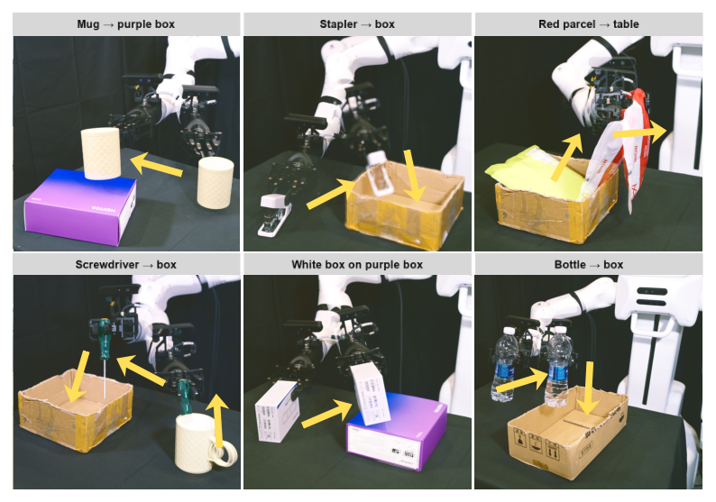

Figure 4. Six-task manipulation suite. Arrows illustrate the object movements required for placement, sorting, and stacking.

Chú thích hình · tiếng Việt

Hình 4. Bộ sáu nhiệm vụ thao tác. Mũi tên minh họa chuyển động của vật cần thực hiện để đặt, phân loại và xếp chồng.

Hình 4 · Phương pháp

**① Chức năng hình**

### Minh họa nhiệm vụ

**② Vai trò logic**

Giúp hình dung độ khó: tua vít cần hai giai đoạn (rút khỏi cốc rồi đặt vào hộp), bưu kiện đòi hỏi chọn đúng vật màu đỏ.

**③ Thủ pháp / điểm yếu tiềm ẩn**

Ảnh tĩnh không cho biết mức biến thiên của vị trí ban đầu giữa các lượt, yếu tố quyết định độ khó thực sự của nhiệm vụ.

4.2–4.3

## Nominal & Perturbed Success Thành công ở điều kiện chuẩn và khi có nhiễu

Bằng chứng chính cho luận đề

### 4.2 · Nominal Task Success · Thành công ở điều kiện chuẩn

§27PDF tr. 6EN → VI

Table 1 summarizes the nominal comparison. Across all six tasks, the frozen SmolVLA policy achieves an aggregate success rate of 60.0%, while GAF reaches 82.5%, an absolute improvement of 22.5 percentage points. GAF improves the observed success rate on every task in the suite.

Bản dịch tiếng Việt

Bảng 1 tóm tắt so sánh ở điều kiện chuẩn. Tính trên cả sáu nhiệm vụ, chính sách SmolVLA đóng băng đạt tỷ lệ thành công gộp 60,0%, còn GAF đạt 82,5%, tức cải thiện tuyệt đối 22,5 điểm phần trăm. GAF nâng tỷ lệ thành công quan sát được ở mọi nhiệm vụ trong bộ thử.

§27 · Bằng chứng

**① Chức năng đoạn**

### Trình bày bằng chứng chính

**② Vai trò logic**

Mắt xích “bằng chứng” trung tâm cho luận đề.

**③ Thủ pháp / điểm yếu tiềm ẩn**

Ở mức gộp (240 lượt mỗi bên: 144 so với 198 lượt thành công), chênh lệch rất rõ; ước tính thô của người biên soạn bằng kiểm định hai tỷ lệ cho z ≈ 5,4. Chữ “observed” là cách rào đón chính xác: riêng Chai (+15 điểm) có khoảng tin cậy chứa 0 (Hình 5a). “Cải thiện ở mọi nhiệm vụ” là nhất quán về hướng, chưa phải có ý nghĩa ở từng nhiệm vụ.

Bảng 1PDF tr. 7Số liệu đầy đủ

Table 1. Nominal task success rates (%). ∆ denotes the gain over Frozen SmolVLA in percentage points.

Chú thích bảng · tiếng Việt

Bảng 1. Tỷ lệ thành công ở điều kiện chuẩn (%). Δ là mức tăng so với SmolVLA đóng băng, tính bằng điểm phần trăm.

Bảng 1

| Task · Nhiệm vụ | Frozen · Đóng băng | GAF | ∆ (pp) |
| --- | --- | --- | --- |
| Bottle · Chai | 70.0% | 85.0% | +15.0 |
| Mug · Cốc | 50.0% | 67.5% | +17.5 |
| Stapler · Dập ghim | 55.0% | 77.5% | +22.5 |
| Parcel · Bưu kiện | 57.5% | 92.5% | +35.0 |
| Screwdriver · Tua vít | 60.0% | 80.0% | +20.0 |
| Stacking · Xếp hộp | 67.5% | 92.5% | +25.0 |
| Aggregate · Gộp | 60.0% | 82.5% | +22.5 |

Bảng 1 · Bằng chứng

**① Chức năng bảng**

### Số liệu chi tiết ở điều kiện chuẩn

**② Vai trò logic**

Cho phép kiểm tra tuyên bố “cải thiện ở mọi nhiệm vụ” và mức gộp 22,5 điểm.

**③ Thủ pháp / điểm yếu tiềm ẩn**

Mức tăng lớn nhất ở Bưu kiện (+35,0) và Xếp hộp (+25,0); nhỏ nhất ở Chai (+15,0), nhiệm vụ có baseline cao nhất (70%). Kiểm tra số học: trung bình các hàng khớp đúng với dòng gộp (60,0 và 82,5) vì mọi nhiệm vụ cùng n = 40. Bảng không kèm khoảng tin cậy.

### 4.3 · Performance under Environment Perturbations · Hiệu năng khi môi trường bị nhiễu

§28PDF tr. 6–7EN → VI

We next test whether the nominal improvement is retained when the task environment is changed (Table 2). The perturbation suite covers altered lighting and additional object distractors on three tasks. Across the six perturbation conditions, the frozen policy achieves an aggregate success rate of 34.2%, compared with 49.2% with GAF, an absolute improvement of 15.0 percentage points. GAF has a positive observed difference in every tested perturbation condition.

Bản dịch tiếng Việt

Tiếp theo, chúng tôi kiểm tra liệu mức cải thiện ở điều kiện chuẩn có được duy trì khi môi trường nhiệm vụ thay đổi hay không (Bảng 2). Bộ thử nhiễu gồm thay đổi ánh sáng và thêm vật gây nhiễu trên ba nhiệm vụ. Trên sáu điều kiện nhiễu, chính sách đóng băng đạt tỷ lệ thành công gộp 34,2%, so với 49,2% khi có GAF, tức cải thiện tuyệt đối 15,0 điểm phần trăm. Ở mọi điều kiện nhiễu được thử, chênh lệch quan sát được đều dương.

§28 · Bằng chứng

**① Chức năng đoạn**

### Kiểm tra độ bền vững

**② Vai trò logic**

Mở rộng bằng chứng: lợi ích không chỉ xuất hiện ở điều kiện giống lúc thu dữ liệu.

**③ Thủ pháp / điểm yếu tiềm ẩn**

Nếu critic chỉ học từ lượt chạy ở điều kiện chuẩn (bài không nói khác), đây là phép thử ngoài phân bố cho cả critic, nên kết quả dương là đáng giá. Nhưng mỗi ô chỉ có 20 lượt; chênh lệch +10 điểm tương ứng 2 lượt. Ở mức gộp (120 lượt mỗi bên), ước tính thô cho z ≈ 2,4: có ý nghĩa nhưng không mạnh. Với GAF, tỷ lệ thất bại vẫn trên 50%.

Bảng 2PDF tr. 8Số liệu đầy đủ

Table 2. Success rates (%) under altered lighting and object-distractor conditions. ∆ denotes the gain over Frozen SmolVLA in percentage points.

Chú thích bảng · tiếng Việt

Bảng 2. Tỷ lệ thành công (%) khi thay đổi ánh sáng và khi có vật gây nhiễu. Δ là mức tăng so với SmolVLA đóng băng, tính bằng điểm phần trăm.

Bảng 2

| Task · Condition | Frozen · Đóng băng | GAF | ∆ (pp) |
| --- | --- | --- | --- |
| Bottle · Altered lighting (Chai · đổi ánh sáng) | 15.0% | 25.0% | +10.0 |
| Bottle · Object distractor (Chai · vật nhiễu) | 25.0% | 45.0% | +20.0 |
| Mug · Altered lighting (Cốc · đổi ánh sáng) | 35.0% | 55.0% | +20.0 |
| Mug · Object distractor (Cốc · vật nhiễu) | 35.0% | 50.0% | +15.0 |
| Stapler · Altered lighting (Dập ghim · đổi ánh sáng) | 45.0% | 60.0% | +15.0 |
| Stapler · Object distractor (Dập ghim · vật nhiễu) | 50.0% | 60.0% | +10.0 |
| Aggregate · Gộp | 34.2% | 49.2% | +15.0 |

Bảng 2 · Bằng chứng

**① Chức năng bảng**

### Số liệu chi tiết khi có nhiễu

**② Vai trò logic**

Cho thấy phạm vi của tuyên bố bền vững: hướng nhất quán, độ lớn khiêm tốn.

**③ Thủ pháp / điểm yếu tiềm ẩn**

Mức suy giảm do nhiễu lớn hơn nhiều so với phần GAF bù lại: Chai giảm từ 70% (chuẩn) xuống 15% khi đổi ánh sáng, và GAF chỉ đưa lên 25%. Nói cách khác, GAF làm hệ thống tốt hơn nhưng chưa làm nó bền vững trước nhiễu.

4.4

## Guidance & Critic-Input Ablations Thí nghiệm loại bỏ: hướng dẫn hướng và đầu vào critic

Phản biện các giải thích thay thế

§29PDF tr. 7EN → VI

Fig. 5 evaluates two properties of the guidance module. Plot (a) compares the learned critic direction with Random Guidance on Bottle-to-box, Parcel sorting, and Stacking boxes. GAF improves success by 15.0, 35.0, and 25.0 percentage points over the frozen policy, whereas Random Guidance gives differences of -5.0, -17.5, and -17.5 percentage points. Pooled across the three tasks, GAF improves success by 25.0 percentage points and Random Guidance is 13.3 percentage points below the frozen policy. The learned direction therefore provides the useful part of the intervention.

Bản dịch tiếng Việt

Hình 5 đánh giá hai đặc tính của mô-đun dẫn hướng. Đồ thị (a) so sánh hướng do critic học được với Dẫn hướng ngẫu nhiên trên các nhiệm vụ Chai vào hộp, Phân loại bưu kiện và Xếp chồng hộp. GAF nâng tỷ lệ thành công lần lượt 15,0; 35,0 và 25,0 điểm phần trăm so với chính sách đóng băng, trong khi Dẫn hướng ngẫu nhiên cho chênh lệch −5,0; −17,5 và −17,5 điểm. Gộp cả ba nhiệm vụ, GAF tăng 25,0 điểm, còn Dẫn hướng ngẫu nhiên thấp hơn chính sách đóng băng 13,3 điểm. Vì vậy, chính hướng học được mới là phần tạo ra giá trị của can thiệp.

§29 · Nhượng bộ / phản biện

**① Chức năng đoạn**

### Bác bỏ một giải thích thay thế

**② Vai trò logic**

Phản biện giả thuyết “nhiễu loạn nhỏ nào cũng có ích” (chẳng hạn vì tăng khám phá). Luận đề chỉ đứng được nếu hướng hiệu chỉnh là yếu tố quyết định.

**③ Thủ pháp / điểm yếu tiềm ẩn**

Đây là đối chứng mạnh nhất của bài: cùng độ lớn, cùng lịch, chỉ khác hướng, và dấu kết quả đảo ngược. Tuy nhiên còn một căng thẳng chưa được giải thích: nếu hiệu chỉnh chỉ khoảng 3% độ phân tán lấy mẫu của chính sách (Hình 6b), vì sao một hướng ngẫu nhiên cùng độ lớn lại làm giảm thành công tới 13–17 điểm? Cơ chế nhạy cảm này cần được làm rõ, hoặc phải loại trừ các yếu tố theo phiên thử (thời điểm, trạng thái phần cứng).

§30PDF tr. 7–8EN → VI

For this direction-control ablation, Random Guidance replaces only the direction of the action-gradient correction. At each guided denoising step, let g = ∇<sub>â</sub>Q<sub>ϕ</sub>(s, z, â) be the same critic gradient used by GAF and draw an independent Gaussian tensor u ∼ 𝒩(0, I) with the full action-chunk shape. We form g<sub>rand</sub> = ‖g‖<sub>2</sub> / (‖u‖<sub>2</sub> + ϵ<sub>num</sub>) · u(11) where ϵ<sub>num</sub> > 0 is a small numerical stabilizer. GAF follows (10), while Random Guidance uses v<sub>t,rand</sub> = v<sub>t</sub> − clip(g<sub>rand</sub>, 1.0) / β(12)

Bản dịch tiếng Việt

Trong thí nghiệm loại bỏ kiểm soát hướng này, Dẫn hướng ngẫu nhiên chỉ thay thế hướng của hiệu chỉnh gradient hành động. Ở mỗi bước khử nhiễu có dẫn hướng, gọi g là chính gradient critic mà GAF dùng, và rút một tenxơ Gauss độc lập u ∼ 𝒩(0, I) có cùng kích thước với khối hành động. Ta lập một vectơ ngẫu nhiên có cùng chuẩn với g theo (11), trong đó ϵ<sub>num</sub> > 0 là một hằng số nhỏ để ổn định số học. GAF dùng công thức (10), còn Dẫn hướng ngẫu nhiên dùng (12).

§30 · Phương pháp

**① Chức năng đoạn**

### Đặc tả đối chứng

**② Vai trò logic**

Bảo đảm đối chứng “chỉ khác một biến”: giữ nguyên độ lớn ‖g‖ ở từng bước, chỉ thay hướng.

**③ Thủ pháp / điểm yếu tiềm ẩn**

Thiết kế khéo: chuẩn hóa theo ‖g‖ ở từng bước nên mọi khác biệt về độ lớn và lịch dẫn hướng đều bị loại trừ. Trong không gian 400 chiều, một hướng ngẫu nhiên gần như trực giao với g, nên đối chứng thực chất so sánh “hướng có thông tin” với “hướng không mang thông tin”.

§31PDF tr. 8EN → VI

Both variants use the same critic computation, action-chunk dimensionality, per-sample clipping, the all-10-step guidance schedule, and 1/β scaling; the uncertainty-gate path is disabled in the deployed configuration. Random Guidance therefore does not select or score candidate actions: it changes only the correction direction. Each random-guidance session uses a fresh recorded session seed and a dedicated random-number generator, so the direction sequence is reproducible conditional on that seed without changing the frozen policy’s flow-noise stream.

Bản dịch tiếng Việt

Hai biến thể dùng chung cách tính critic, số chiều khối hành động, phép cắt theo từng mẫu, lịch dẫn hướng ở cả 10 bước và hệ số 1/β; nhánh cổng bất định bị tắt trong cấu hình triển khai. Như vậy, Dẫn hướng ngẫu nhiên không chọn hay chấm điểm hành động ứng viên nào; nó chỉ thay đổi hướng hiệu chỉnh. Mỗi phiên dẫn hướng ngẫu nhiên dùng một seed phiên mới được ghi lại cùng một bộ sinh số ngẫu nhiên riêng, nhờ đó chuỗi hướng có thể tái lập khi biết seed mà không làm xáo trộn chuỗi nhiễu khởi tạo của quá trình dòng trong chính sách đóng băng.

§31 · Nhượng bộ / phản biện

**① Chức năng đoạn**

### Phòng ngừa phản bác về tính công bằng

**② Vai trò logic**

Trả lời trước câu hỏi “đối chứng có bị làm yếu đi không?” bằng cách liệt kê mọi yếu tố được giữ nguyên.

**③ Thủ pháp / điểm yếu tiềm ẩn**

Chi tiết tách bộ sinh số ngẫu nhiên là dấu hiệu cẩn thận hiếm thấy. Điều còn thiếu không nằm ở thuật toán mà ở quy trình thực địa: các phiên ngẫu nhiên, GAF và baseline có được chạy xen kẽ trong cùng điều kiện hay không.

§32PDF tr. 8EN → VI

Plot (b) compares the full critic, which receives visual features, robot state, and the action chunk, with the no-vision critic and no-state critic, which omit visual features and robot state, respectively. All three use the same VLA inputs. Pooled across Bottle-to-box and Stacking boxes, the success-rate differences relative to Frozen SmolVLA are +20.0 percentage points for the full critic, -21.3 for the no-vision critic, and -17.5 for the no-state critic. These results indicate that visual context and robot state both contribute to effective guidance.

Bản dịch tiếng Việt

Đồ thị (b) so sánh critic đầy đủ, vốn nhận đặc trưng thị giác, trạng thái robot và khối hành động, với critic không thị giác và critic không trạng thái, lần lượt bỏ đặc trưng thị giác và trạng thái robot. Cả ba đều dùng cùng đầu vào cho VLA. Gộp hai nhiệm vụ Chai vào hộp và Xếp chồng hộp, chênh lệch tỷ lệ thành công so với SmolVLA đóng băng là +20,0 điểm phần trăm với critic đầy đủ, −21,3 với critic không thị giác và −17,5 với critic không trạng thái. Kết quả này cho thấy cả bối cảnh thị giác lẫn trạng thái robot đều góp phần tạo nên dẫn hướng hiệu quả.

§32 · Bằng chứng

**① Chức năng đoạn**

### Bằng chứng về vai trò của đầu vào

**② Vai trò logic**

Hỗ trợ khái niệm “có điều kiện theo quan sát”: thiếu bất kỳ đầu vào nào, critic trở nên có hại.

**③ Thủ pháp / điểm yếu tiềm ẩn**

Kết luận “đều góp phần” đúng nhưng nói nhẹ: dữ liệu cho thấy critic thiếu thông tin không chỉ vô ích mà còn gây hại rõ rệt (dưới baseline). Điều đó có nghĩa GAF không có cơ chế an toàn khi critic kém, một rủi ro triển khai, nhất là khi cổng bất định đang tắt. Thí nghiệm chỉ gồm 2 nhiệm vụ.

Hình 5PDF tr. 8Ảnh trích từ PDF

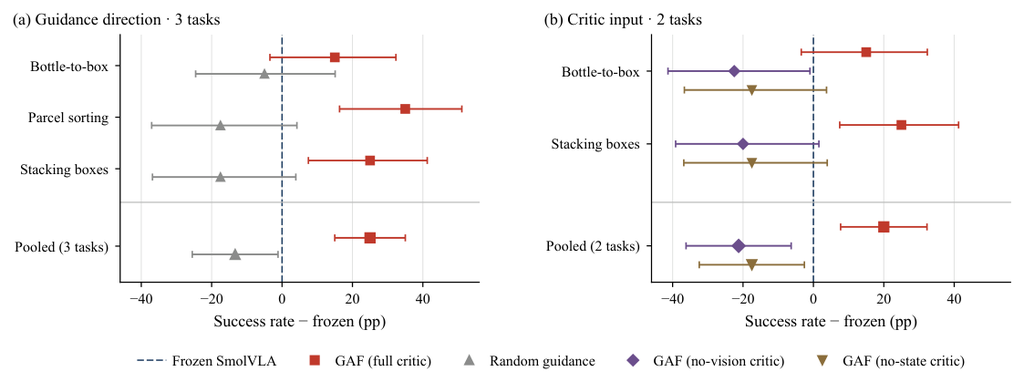

Figure 5. Guidance-direction and critic-input ablations (40 episodes per method and task). Differences are relative to Frozen SmolVLA, with 95% confidence intervals. (a) GAF with the full critic versus Random Guidance. (b) Full, no-vision, and no-state critics; VLA inputs are unchanged.

Chú thích hình · tiếng Việt

Hình 5. Thí nghiệm loại bỏ về hướng dẫn hướng và đầu vào critic (40 lượt cho mỗi phương pháp và nhiệm vụ). Chênh lệch tính so với SmolVLA đóng băng, kèm khoảng tin cậy 95%. (a) GAF với critic đầy đủ so với Dẫn hướng ngẫu nhiên. (b) Critic đầy đủ, không thị giác và không trạng thái; đầu vào của VLA không đổi.

Hình 5 · Bằng chứng

**① Chức năng hình**

### Trực quan hóa hai đối chứng

**② Vai trò logic**

Bằng chứng thị giác cho mắt xích “phản biện”: hướng học được và đầu vào đầy đủ đều cần thiết.

**③ Thủ pháp / điểm yếu tiềm ẩn**

Đọc khoảng tin cậy: ở từng nhiệm vụ, khoảng của GAF trên Chai vào hộp cắt qua 0, và nhiều khoảng của Dẫn hướng ngẫu nhiên cũng chạm 0. Kết luận vững chủ yếu nằm ở các hàng “Pooled”; đó là cách đọc đúng của hình này.

4.5

## Mechanism Diagnostics Chẩn đoán cơ chế

Critic học được gì và can thiệp lớn đến đâu

§33PDF tr. 9EN → VI

Fig. 6 examines the learned critic and the scale of its inference-time intervention. Plot (a) uses a separate held-out cohort of 40 offline Bottle-to-box episodes, excluded from critic training and checkpoint selection. Within each progress interval, an episode is represented by its median critic score. The episode-level AUROC for separating successful and failed episodes rises from 0.664 in the first interval to 0.997 in the final interval. Taking each episode’s median across intervals yields an overall AUROC of 0.970. The critic scores therefore distinguish task outcomes more clearly as execution progresses.

Bản dịch tiếng Việt

Hình 6 xem xét critic đã học và quy mô can thiệp của nó lúc suy luận. Đồ thị (a) dùng một nhóm riêng gồm 40 lượt Chai vào hộp ngoại tuyến, không tham gia huấn luyện critic hay chọn checkpoint. Trong mỗi khoảng tiến độ, một lượt được đại diện bằng trung vị điểm critic của nó. AUROC theo lượt trong việc phân tách lượt thành công với lượt thất bại tăng từ 0,664 ở khoảng đầu lên 0,997 ở khoảng cuối. Lấy trung vị của mỗi lượt trên mọi khoảng cho AUROC tổng thể 0,970. Như vậy, điểm của critic phân biệt kết quả nhiệm vụ ngày càng rõ khi quá trình thực thi tiến triển.

§33 · Bằng chứng

**① Chức năng đoạn**

### Kiểm chứng critic học được điều có nghĩa

**② Vai trò logic**

Bằng chứng gián tiếp rằng gradient của critic mang thông tin về thành và bại.

**③ Thủ pháp / điểm yếu tiềm ẩn**

Tập giữ lại riêng là thực hành tốt. Nhưng AUROC cao ở cuối lượt là điều dễ đạt, vì lúc đó thành/bại gần như nhìn thấy được (vật đã vào hộp hay chưa). Điều quan trọng cho dẫn hướng là giai đoạn đầu và giữa, nơi AUROC 0,664 có khoảng tin cậy chạm mức may rủi (Hình 6a). AUROC đo khả năng phân loại giữa các lượt, không đo độ chính xác của ∇Q theo hành động.

§34PDF tr. 9EN → VI

Plot (b) divides the norm of the GAF–baseline action difference by the median pairwise distance between frozen-policy samples at the same observation. The GAF and baseline chunks share the same initial noise. The medians across episodes are 0.027, 0.045, and 0.028 for Bottle-to-box, Parcel sorting, and Stacking boxes, respectively, indicating small action adjustments relative to the frozen policy’s sampling variation.

Bản dịch tiếng Việt

Đồ thị (b) chia chuẩn của chênh lệch hành động giữa GAF và baseline cho khoảng cách cặp trung vị giữa các mẫu của chính sách đóng băng tại cùng một quan sát. Khối hành động của GAF và baseline dùng chung nhiễu khởi tạo. Trung vị theo lượt lần lượt là 0,027; 0,045 và 0,028 cho Chai vào hộp, Phân loại bưu kiện và Xếp chồng hộp, cho thấy hiệu chỉnh hành động rất nhỏ so với độ biến thiên lấy mẫu tự nhiên của chính sách đóng băng.

§34 · Nhượng bộ / phản biện

**① Chức năng đoạn**

### Đo quy mô can thiệp

**② Vai trò logic**

Phản biện ngầm mối lo “đẩy hành động ra ngoài phân bố”: GAF chỉ là một cú huých nhỏ quanh đề xuất của chính sách.

**③ Thủ pháp / điểm yếu tiềm ẩn**

Con dao hai lưỡi: hiệu chỉnh chỉ khoảng 3–4,5% độ phân tán tự nhiên, nhỏ hơn hẳn việc đổi seed nhiễu, vậy mà được gắn với mức +22,5 điểm thành công. Hoặc thành công nhạy rất mạnh với những hướng rất cụ thể (cần phân tích thêm), hoặc còn yếu tố khác góp phần. Bài trình bày con số này như một điểm mạnh mà không đối diện với câu hỏi đó.

§35PDF tr. 9EN → VI

Plot (c) shows increasing RMS action deviation as the guidance coefficient increases in an offline replay of Bottle-to-box observations. At the deployed setting α = 1/β = 0.5, the mean deviations are 1.09 × 10<sup>−3</sup> for joint channels and 1.38 × 10<sup>−3</sup> for the gripper in normalized action units. The sweep characterizes how β controls the size of the intervention.

Bản dịch tiếng Việt

Đồ thị (c) cho thấy độ lệch hành động RMS tăng theo hệ số dẫn hướng trong một phép phát lại ngoại tuyến các quan sát của nhiệm vụ Chai vào hộp. Ở thiết lập triển khai α = 1/β = 0,5, độ lệch trung bình là 1,09 × 10⁻³ cho các kênh khớp và 1,38 × 10⁻³ cho bộ kẹp, tính theo đơn vị hành động đã chuẩn hóa. Phép quét này mô tả cách β điều khiển độ lớn của can thiệp.

§35 · Phương pháp

**① Chức năng đoạn**

### Phân tích độ nhạy siêu tham số

**② Vai trò logic**

**③ Thủ pháp / điểm yếu tiềm ẩn**

Phép quét chỉ đo độ lệch, không đo thành công: chưa biết α lớn hơn sẽ tốt hơn hay phá hỏng hành vi, tức chưa có cơ sở thực nghiệm cho việc chọn α = 0,5. Độ lệch cỡ 10⁻³ trong không gian chuẩn hóa càng làm nổi bật câu hỏi ở đoạn trước.

§36PDF tr. 9–10EN → VI

Plot (d) probes action sensitivity on Bottle-to-box while holding the observation fixed. We either shuffle the original chunk along its temporal dimension or replace it with a chunk from another episode at matched or different normalized progress. The absolute change in Q is normalized by the maximum-minus-minimum Q score among four frozen-policy candidate chunks generated at that observation. The medians across episodes are 0.61 for temporal shuffling, 9.04 for matched-progress substitutions, and 24.35 for different-progress substitutions. These responses show sensitivity to action content, with larger score changes for chunks drawn from other episodes, especially at different progress.

Bản dịch tiếng Việt

Đồ thị (d) thăm dò độ nhạy của critic với hành động trên nhiệm vụ Chai vào hộp, trong khi giữ nguyên quan sát. Chúng tôi hoặc xáo trộn khối gốc theo chiều thời gian, hoặc thay nó bằng một khối lấy từ lượt khác ở cùng hoặc khác tiến độ chuẩn hóa. Độ thay đổi tuyệt đối của Q được chuẩn hóa bằng hiệu giữa điểm Q lớn nhất và nhỏ nhất trong bốn khối ứng viên do chính sách đóng băng sinh ra tại quan sát đó. Trung vị theo lượt là 0,61 khi xáo trộn thời gian, 9,04 khi thay bằng khối cùng tiến độ và 24,35 khi thay bằng khối khác tiến độ. Các phản ứng này cho thấy critic nhạy với nội dung hành động, với mức thay đổi điểm lớn hơn khi khối đến từ lượt khác, nhất là khi khác tiến độ.

§36 · Bằng chứng

**① Chức năng đoạn**

### Kiểm tra critic có thực sự “nhìn” hành động

**② Vai trò logic**

Bác bỏ khả năng critic chỉ dựa vào quan sát và bỏ qua a; nếu vậy, ∇Q sẽ vô nghĩa.

**③ Thủ pháp / điểm yếu tiềm ẩn**

Giá trị 0,61 < 1 khi xáo trộn thời gian là điểm yếu được trình bày như điểm mạnh: phá vỡ trật tự thời gian của cả khối 50 bước chỉ làm Q đổi ít hơn khoảng chênh giữa các ứng viên hợp lệ, tức critic gần như không nhạy với cấu trúc thời gian. Phản ứng mạnh với khối “ngoại lai” có thể chỉ phản ánh việc nhận ra hành động ngoài phân bố hoặc lệch tiến độ, hơn là đánh giá chất lượng ở mức tinh.

Hình 6PDF tr. 9Ảnh trích từ PDF

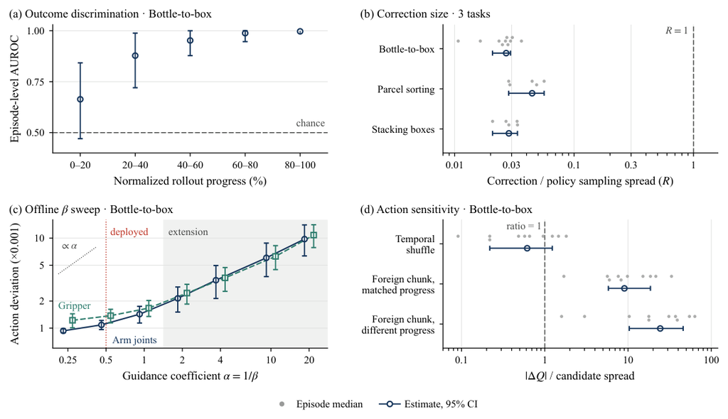

Figure 6. Mechanism diagnostics for GAF. (a) Episode-level area under the receiver operating characteristic curve (AUROC) across normalized rollout progress. (b) Action correction relative to the frozen policy’s action-sampling spread on three tasks, with β = 2. (c) Offline Bottle-to-box sweep: root-mean-square (RMS) action deviation in normalized units versus α = 1/β; the deployed setting is α = 0.5. (d) Absolute critic-score change under action substitution, relative to the Q-score range of policy candidates at the same observation. Error bars show 95% episode-bootstrap confidence intervals.

Chú thích hình · tiếng Việt

Hình 6. Chẩn đoán cơ chế của GAF. (a) Diện tích dưới đường cong ROC (AUROC) theo lượt, theo tiến độ chuẩn hóa của lượt chạy. (b) Độ lớn hiệu chỉnh hành động so với độ phân tán lấy mẫu của chính sách đóng băng trên ba nhiệm vụ, với β = 2. (c) Quét ngoại tuyến trên Chai vào hộp: độ lệch hành động RMS (đơn vị chuẩn hóa) theo α = 1/β; thiết lập triển khai là α = 0,5. (d) Độ thay đổi tuyệt đối của điểm critic khi thay thế hành động, so với biên độ điểm Q của các ứng viên từ chính sách tại cùng quan sát. Thanh sai số là khoảng tin cậy bootstrap 95% theo lượt.

Hình 6 · Bằng chứng

**① Chức năng hình**

### Bảng chẩn đoán cơ chế

**② Vai trò logic**

Bốn góc nhìn bổ sung cho câu hỏi “vì sao GAF hoạt động”.

**③ Thủ pháp / điểm yếu tiềm ẩn**

Ba trong bốn đồ thị chỉ dùng Chai vào hộp, nhiệm vụ có mức tăng nhỏ nhất và không có ý nghĩa thống kê khi xét riêng. Nhiệm vụ tăng mạnh nhất (Bưu kiện, +35 điểm) chỉ xuất hiện ở đồ thị (b).

5

## Discussion Thảo luận

Thông điệp khép lại và hướng tiếp theo

§37PDF tr. 10EN → VI

The critic-input ablations reveal that multimodal conditioning matters beyond the VLA’s action generator. Although the VLA receives the same images and robot state in all conditions, omitting either modality from the critic lowers success below the frozen baseline on the evaluated tasks. Information available to the policy therefore does not automatically compensate for missing context in the guidance signal. Together with the small correction sizes in plot (b) of Fig. 6, this finding highlights the role of observation-conditioned value estimates in directing local changes to a policy proposal. Future work can extend observation-conditioned guidance across broader task and workspace variation and adapt its schedule to observed uncertainty.

Bản dịch tiếng Việt

Các thí nghiệm loại bỏ đầu vào critic cho thấy việc điều kiện hóa đa phương thức có vai trò riêng, độc lập với phần sinh hành động của VLA. Dù VLA nhận cùng hình ảnh và trạng thái robot trong mọi điều kiện, việc bỏ bất kỳ phương thức nào khỏi critic đều kéo tỷ lệ thành công xuống dưới baseline đóng băng trên các nhiệm vụ được đánh giá. Do đó, thông tin mà chính sách có được không tự động bù đắp cho phần bối cảnh bị thiếu trong tín hiệu dẫn hướng. Kết hợp với độ lớn hiệu chỉnh nhỏ ở Hình 6(b), phát hiện này nhấn mạnh vai trò của các ước lượng giá trị có điều kiện theo quan sát trong việc định hướng những thay đổi cục bộ cho đề xuất của chính sách. Các nghiên cứu tiếp theo có thể mở rộng dẫn hướng có điều kiện theo quan sát sang những biến thể nhiệm vụ và không gian làm việc rộng hơn, đồng thời điều chỉnh lịch dẫn hướng theo mức bất định quan sát được.

§37 · Luận đề

**① Chức năng đoạn**

### Tổng kết và diễn giải

**② Vai trò logic**

Mắt xích “kết luận”: chọn một phát hiện (vai trò của đầu vào đa phương thức) làm thông điệp chính, thay vì nhắc lại con số thành công.

**③ Thủ pháp / điểm yếu tiềm ẩn**

Phần Thảo luận rất ngắn và không có mục Hạn chế riêng: không bàn về chi phí suy luận, critic riêng cho từng nhiệm vụ, chỉ một robot và một VLA, cỡ mẫu nhỏ, hay việc thiếu đối chứng với RL fine-tuning và xếp hạng ứng viên. Hạn chế chỉ được thừa nhận gián tiếp qua “future work”. Bài cũng không có mục Kết luận độc lập.

Ref.

## References Tài liệu tham khảo

40 tài liệu, nhóm theo vai trò trong lập luận

VLA & generalist policies · Nền tảng VLA7 tài liệu

1. B. Zitkovich et al., “RT-2: Vision-language-action models transfer web knowledge to robotic control,” in Proc. Conf. Robot Learn. (CoRL), ser. Proc. Mach. Learn. Res., vol. 229, 2023, pp. 2165–2183.
2. M. J. Kim et al., “OpenVLA: An open-source vision-language-action model,” in Proc. Conf. Robot Learn. (CoRL), ser. Proc. Mach. Learn. Res., vol. 270, 2025, pp. 2679–2713.
3. K. Black et al., “π0: A vision-language-action flow model for general robot control,” in Proc. Robot.: Sci. Syst. (RSS), 2025, doi: 10.15607/RSS.2025.XXI.010.
4. X. Tan et al., “SignVLA: A gloss-free vision-language-action framework for real-time sign language-guided robotic manipulation,” arXiv:2602.22514, 2026.
5. D. Ghosh et al., “Octo: An open-source generalist robot policy,” in Proc. Robot.: Sci. Syst. (RSS), 2024, doi: 10.15607/RSS.2024.XX.090.
6. K. Pertsch et al., “FAST: Efficient action tokenization for vision-language-action models,” in Proc. Robot.: Sci. Syst. (RSS), 2025, doi: 10.15607/RSS.2025.XXI.012.
7. M. Shukor et al., “SmolVLA: A vision-language-action model for affordable and efficient robotics,” arXiv:2506.01844, 2025.

Mô tả nhóm · tiếng Việt

Nhóm nền tảng: các mô hình VLA và chính sách robot tổng quát (RT-2, OpenVLA, π0, Octo, FAST), cùng SmolVLA [13], chính mô hình được đóng băng trong bài.

Nhóm tài liệu · Khái niệm

**① Chức năng nhóm trích dẫn**

### Dựng nền khái niệm

**② Vai trò logic**

Xác định đối tượng của can thiệp; [3] π0 và [13] SmolVLA là hai VLA khớp dòng, điều kiện tiên quyết để GAF hoạt động.

**③ Thủ pháp / điểm yếu tiềm ẩn**

Phần nền tảng đầy đủ và cập nhật. [10] SignVLA (ngôn ngữ ký hiệu) liên hệ khá xa với bài toán.

RL post-training & value learning for robots · Học tăng cường và học giá trị cho robot6 tài liệu

1. S. Tan, K. Dou, Y. Zhao, and P. Krähenbühl, “Interactive post-training for vision-language-action models,” arXiv:2505.17016, 2025.
2. H. Li et al., “SimpleVLA-RL: Scaling VLA training via reinforcement learning,” in Proc. Int. Conf. Learn. Represent. (ICLR), 2026.
3. K. Chen et al., “πRL: Online RL fine-tuning for flow-based vision-language-action models,” arXiv:2510.25889, 2025.
4. D. Kalashnikov et al., “Scalable deep reinforcement learning for vision-based robotic manipulation,” in Proc. Conf. Robot Learn. (CoRL), ser. Proc. Mach. Learn. Res., vol. 87, 2018, pp. 651–673.
5. I. Kostrikov, A. Nair, and S. Levine, “Offline reinforcement learning with implicit Q-learning,” in Proc. Int. Conf. Learn. Represent. (ICLR), 2022.
6. Y. Chen, S. Tian, S. Liu, Y. Zhou, H. Li, and D. Zhao, “ConRFT: A reinforced fine-tuning method for VLA models via consistency policy,” in Proc. Robot.: Sci. Syst. (RSS), 2025, doi: 10.15607/RSS.2025.XXI.019.

Mô tả nhóm · tiếng Việt

Nhóm “đối thủ”: các phương pháp hậu huấn luyện VLA bằng RL [4–6], học giá trị cho thao tác thị giác [34], IQL [35] (thuật toán critic của bài) và tinh chỉnh tăng cường ConRFT [36].

Nhóm tài liệu · Nhượng bộ / phản biện

**① Chức năng nhóm trích dẫn**

### Định nghĩa phương án thay thế

**② Vai trò logic**

Là nhánh “cập nhật tham số” mà GAF tự định vị đối lập; [35] cung cấp trực tiếp công cụ huấn luyện critic.

**③ Thủ pháp / điểm yếu tiềm ẩn**

Đây đúng là các phương pháp lẽ ra cần đưa vào thực nghiệm làm đối chứng có cùng dữ liệu; bài chỉ nhắc đến chúng ở phần tổng quan.

Test-time guidance · Dẫn hướng lúc kiểm thử6 tài liệu

1. M. Nakamoto, O. Mees, A. Kumar, and S. Levine, “Steering your generalists: Improving robotic foundation models via value guidance,” in Proc. Conf. Robot Learn. (CoRL), ser. Proc. Mach. Learn. Res., vol. 270, 2025, pp. 4996–5013.
2. Z. Zhou et al., “Test-time gradient guidance of flow policies in reinforcement learning,” arXiv:2606.11087, 2026.
3. P. Dhariwal and A. Nichol, “Diffusion models beat GANs on image synthesis,” in Adv. Neural Inf. Process. Syst., vol. 34, 2021, pp. 8780–8794.
4. J. Ho and T. Salimans, “Classifier-free diffusion guidance,” arXiv:2207.12598, 2022.
5. M. Janner, Y. Du, J. Tenenbaum, and S. Levine, “Planning with diffusion for flexible behavior synthesis,” in Proc. Int. Conf. Mach. Learn. (ICML), ser. Proc. Mach. Learn. Res., vol. 162, 2022, pp. 9902–9915.
6. P. Hansen-Estruch, I. Kostrikov, M. Janner, J. G. Kuba, and S. Levine, “IDQL: Implicit Q-learning as an actor-critic method with diffusion policies,” arXiv:2304.10573, 2023.

Mô tả nhóm · tiếng Việt

Nhóm cơ chế: lái chính sách bằng hàm giá trị V-GPS [7], dẫn hướng gradient cho chính sách dòng [8], dẫn hướng có và không có bộ phân loại trong sinh ảnh [37, 38], Diffuser [39] và IDQL [40].

Nhóm tài liệu · Phương pháp

**① Chức năng nhóm trích dẫn**

### Truy nguồn cơ chế

**② Vai trò logic**

Phả hệ trực tiếp của GAF; [8] là tiền thân gần nhất về thuật toán, [7] là phương án thay thế dựa trên xếp hạng ứng viên.

**③ Thủ pháp / điểm yếu tiềm ẩn**

Trích dẫn trung thực về nguồn gốc ý tưởng. Do [8] gần như là cùng cơ chế, đóng góp của GAF chủ yếu nằm ở bối cảnh áp dụng và đánh giá.

Feedback control, detection & multi-agent systems · Điều khiển phản hồi, phát hiện vật thể, hệ đa tác tử13 tài liệu

1. H. Zhao et al., “Real-time object detection and robotic manipulation for agriculture using a YOLO-based learning approach,” in Proc. IEEE Int. Conf. Ind. Technol. (ICIT), 2024, pp. 1–6, doi: 10.1109/icit58233.2024.10540740.
2. Z. Tang, C. Wang, and Z. Ding, “Unmatched disturbance rejection for AMB systems via DOBC approach,” in Proc. Chin. Control Conf. (CCC), 2016, pp. 5931–5935, doi: 10.1109/chicc.2016.7554287.
3. Z.-z. Tang, Y.-j. Yu, Z.-h. Li, and Z.-t. Ding, “Disturbance rejection via iterative learning control with a disturbance observer for active magnetic bearing systems,” Front. Inf. Technol. Electron. Eng., vol. 20, no. 1, pp. 131–140, 2019, doi: 10.1631/fitee.1800558.
4. Z. Tang, C. Passmore, J. A. Rossiter, S. Ebbens, G. Dunderdale, and G. Panoutsos, “Disturbance observer-based optimal tracking control for slot coating process with mismatched input disturbances,” in Proc. UKACC Int. Conf. Control (CONTROL), 2024, pp. 55–56, doi: 10.1109/control60310.2024.10531965.
5. Z. Tang et al., “Disturbance observer-based tracking control for roll-to-roll slot die coating systems under gap and pump rate disturbances,” arXiv:2601.08488, 2026.
6. Z. Tang, J. A. Rossiter, X. Jin, B. Zhang, and G. Panoutsos, “Output tracking for uncertain time-delay systems via robust reinforcement learning control,” in Proc. Chin. Control Conf. (CCC), 2024, pp. 2219–2226, doi: 10.23919/ccc63176.2024.10662811.
7. Z. Tang, J. A. Rossiter, Y. Dong, and G. Panoutsos, “Reinforcement learning-based output stabilization control for nonlinear systems with generalized disturbances,” in Proc. IEEE Int. Conf. Ind. Technol. (ICIT), 2024, pp. 1–6, doi: 10.1109/icit58233.2024.10540609.
8. Z. Tang, J. A. Rossiter, and G. Panoutsos, “A reinforcement learning-based approach for optimal output tracking in uncertain nonlinear systems with mismatched disturbances,” in Proc. UKACC Int. Conf. Control (CONTROL), 2024, pp. 169–174, doi: 10.1109/control60310.2024.10532060.
9. N. Bai, C. P. Chan, Q. Yin, T. Gong, Y. Yan, and Z. Tang, “Deep reinforcement learning optimization for uncertain nonlinear systems via event-triggered robust adaptive dynamic programming,” arXiv:2512.15735, 2025.
10. Z. Luo, P. Zhang, X. Ding, Z. Tang, C. Wang, and J. Wang, “Adaptive affine formation maneuver control of second-order multi-agent systems with disturbances,” in Proc. Int. Conf. Control Autom. Robot. Vis. (ICARCV), 2020, pp. 1071–1076, doi: 10.1109/icarcv50220.2020.9305372.
11. O. Onuoha, B. C. Ubochi, S. Kurawa, Z. Tang, C. Wu, and Y. Dong, “Stress matrix-based formation control of multi-agent systems with discrete-time communication,” in Proc. Int. Conf. Syst. Control (ICSC), 2024, pp. 173–177, doi: 10.1109/icsc63929.2024.10928839.
12. T. Gong, Y. Xu, Z. Li, Z. Tang, and Z. Ding, “Distributed time-varying optimization with inequality constraints via prescribed-time distributed average tracking,” in Proc. Chin. Control Conf. (CCC), 2025, pp. 2272–2277, doi: 10.23919/ccc64809.2025.11179599.
13. J. Hu, Z. Tang, X. Jin, B. Zhang, Y. Dong, and X. Huang, “Hierarchical testing with rabbit optimization for industrial cyber-physical systems,” IEEE Trans. Ind. Cyber-Phys. Syst., vol. 3, pp. 472–484, 2025, doi: 10.1109/ticps.2025.3586988.

Mô tả nhóm · tiếng Việt

Nhóm bối cảnh rộng: phát hiện vật thể bằng YOLO cho nông nghiệp [9], điều khiển dựa trên bộ quan sát nhiễu cho ổ từ và phủ màng [14–17], RL cho bám quỹ đạo và ổn định hóa [18–21], điều khiển đội hình đa tác tử [22–24] và kiểm thử hệ thống vật lý–mạng [25].

Nhóm tài liệu · Nhượng bộ / phản biện

**① Chức năng nhóm trích dẫn**

### Mở rộng bối cảnh (liên hệ yếu)

**② Vai trò logic**

Hỗ trợ câu phân loại “phản hồi cập nhật tham số hay tác động vào cách chọn hành động” ở Mục 2.2.

**③ Thủ pháp / điểm yếu tiềm ẩn**

Cả 12 tài liệu [14–25] đều có Z. Tang (tác giả liên hệ); cộng thêm [32, 33] của tác giả thứ nhất, ít nhất 14/40 tài liệu là tự trích dẫn. Phần lớn nhóm này không liên quan trực tiếp đến VLA hay dẫn hướng lúc suy luận.

Language-model post-training · Hậu huấn luyện mô hình ngôn ngữ8 tài liệu

1. L. Ouyang et al., “Training language models to follow instructions with human feedback,” in Adv. Neural Inf. Process. Syst., vol. 35, 2022, pp. 27 730–27 744, doi: 10.52202/068431-2011.
2. Y. Bai et al., “Constitutional AI: Harmlessness from AI feedback,” arXiv:2212.08073, 2022.
3. H. Lightman et al., “Let’s verify step by step,” in Proc. Int. Conf. Learn. Represent. (ICLR), 2024.
4. C. Gulcehre et al., “Reinforced self-training (ReST) for language modeling,” arXiv:2308.08998, 2023.
5. Z. Shao et al., “DeepSeekMath: Pushing the limits of mathematical reasoning in open language models,” arXiv:2402.03300, 2024.
6. C. Zheng et al., “Group sequence policy optimization,” arXiv:2507.18071, 2025.
7. L. Yang et al., “Post-training for reasoning LLMs with reinforcement learning: A stability– efficiency perspective,” in Proc. Int. Conf. Autom. Comput. (ICAC), 2026.
8. L. Yang et al., “Reinforcement learning post-training for reasoning large language models: Methods, systems, and evaluation,” Unmanned Syst., Sep. 2026, early access, doi: 10.1142/S2301385028300065.

Mô tả nhóm · tiếng Việt

Nhóm liên hệ chéo: RLHF [26], Constitutional AI [27], giám sát theo quá trình [28], ReST [29], DeepSeekMath/GRPO [30], GSPO [31] và hai bài tổng quan về hậu huấn luyện LLM bằng RL [32, 33].

Nhóm tài liệu · Khái niệm

**① Chức năng nhóm trích dẫn**

### Tạo tính chính danh liên ngành

**② Vai trò logic**

Cho thấy “phản hồi nhiệm vụ cải thiện chính sách” là ý tưởng đã thành công ở LLM.

**③ Thủ pháp / điểm yếu tiềm ẩn**

Tất cả đều thuộc nhánh cập nhật tham số, nên không hỗ trợ trực tiếp lựa chọn đóng băng của GAF.

Synthesis / Tổng quan cuối bài

## Lập luận của bài báo đứng vững ở đâu?

**Luận đề trong một câu:** Một critic Q nhỏ (khoảng 2,7 triệu tham số), học ngoại tuyến từ kết quả thành/bại của vài chục lượt chạy, đủ để nâng rõ rệt tỷ lệ thành công của một VLA khớp dòng đã đóng băng chỉ bằng cách chen gradient theo hành động vào từng bước lấy mẫu dòng ngược, mà không phải chạm vào tham số của VLA.

Khung logic · nhấn một bước để trở lại đoạn tương ứng

1. 1 · Câu hỏi / §03**Kết quả của các lượt chạy thử có thể cải thiện hành động của VLA ngay khi triển khai, mà không cập nhật tham số, hay không?**
2. 2 · Luận điểm / Mục 3, §22**Có: học critic Q bằng IQL từ 40 lượt mỗi nhiệm vụ, rồi dùng ∇Q tại hành động ước lượng â để hiệu chỉnh vận tốc dòng ngược ở cả 10 bước.**
3. 3 · Bằng chứng / Bảng 1–2, Hình 6**Thành công gộp 60,0% → 82,5% (chuẩn, 6 nhiệm vụ) và 34,2% → 49,2% (6 điều kiện nhiễu); critic phân biệt thành/bại với AUROC tổng thể 0,970.**
4. 4 · Phản biện & nhượng bộ / Mục 4.4–4.5, 3.6**Hướng ngẫu nhiên cùng độ lớn làm giảm 13,3 điểm, nên không phải “nhiễu nào cũng có ích”; critic thiếu đầu vào gây hại; hiệu chỉnh chỉ khoảng 3% độ phân tán; an toàn giao cho tầng robot.**
5. 5 · Kết luận / Mục 5**Ước lượng giá trị có điều kiện theo quan sát có thể định hướng những thay đổi cục bộ cho đề xuất của một VLA đóng băng; mở rộng sang biến thể rộng hơn là việc của tương lai.**

### Điểm mạnh nhất · Đối chứng hướng ngẫu nhiên có cùng độ lớn

Hình 5(a) giữ nguyên critic, độ lớn ‖g‖ ở từng bước, phép cắt, lịch 10 bước và hệ số 1/β; chỉ thay hướng. Kết quả gộp đảo dấu: +25,0 điểm với hướng học được so với −13,3 điểm với hướng ngẫu nhiên. Cùng với việc critic thiếu thị giác hoặc thiếu trạng thái đều rơi xuống dưới baseline (Hình 5b), đây là bằng chứng có kiểm soát rằng thông tin trong hướng gradient, chứ không phải bản thân sự nhiễu loạn, tạo ra mức cải thiện.

### Điểm yếu nhất · Đối chứng duy nhất là “không làm gì”

GAF dùng thêm 40 lượt chạy có nhãn thành/bại cho mỗi nhiệm vụ, nhưng chỉ được so với chính sách đóng băng. Không có phương án nào dùng cùng dữ liệu đó theo cách khác: tinh chỉnh thêm trên các lượt thành công, hậu huấn luyện RL [4–6, 36], hay xếp hạng lại ứng viên bằng cùng critic [7]. Vì vậy bài chứng minh được rằng GAF *tốt hơn không làm gì*, nhưng chưa chứng minh rằng dẫn hướng lúc suy luận là cách dùng dữ liệu chạy thử *tốt nhất* hay rẻ nhất. Chi phí độ trễ cũng không được báo cáo (§24).

### Đối chiếu số học · tỷ lệ thất bại giảm bao nhiêu?

| Bộ thử | Lượt / bên | Thất bại · Frozen | Thất bại · GAF | Giảm tương đối |
| --- | --- | --- | --- | --- |
| Chuẩn · 6 nhiệm vụ | 240 | 96 (40,0%) | 42 (17,5%) | 56,3% |
| Nhiễu · 6 điều kiện | 120 | 79 (65,8%) | 61 (50,8%) | 22,8% |

Tính từ Bảng 1–2 (số lượt = tỷ lệ × n): giảm tương đối = 1 − thất bại GAF / thất bại Frozen. Ở điều kiện chuẩn, GAF loại bỏ hơn một nửa số lần thất bại; khi có nhiễu, chưa đến một phần tư. Đây là phép tính thêm của người biên soạn để thấy rõ khoảng cách giữa hai bộ thử, không phải một thí nghiệm mới.